# DETERMINING THE CAUSAL LINKS BETWEEN REPRODUCTIVE TIMING AND METABOLIC RISK: A BIDIRECTIONAL MENDELIAN RANDOMIZATION STUDY

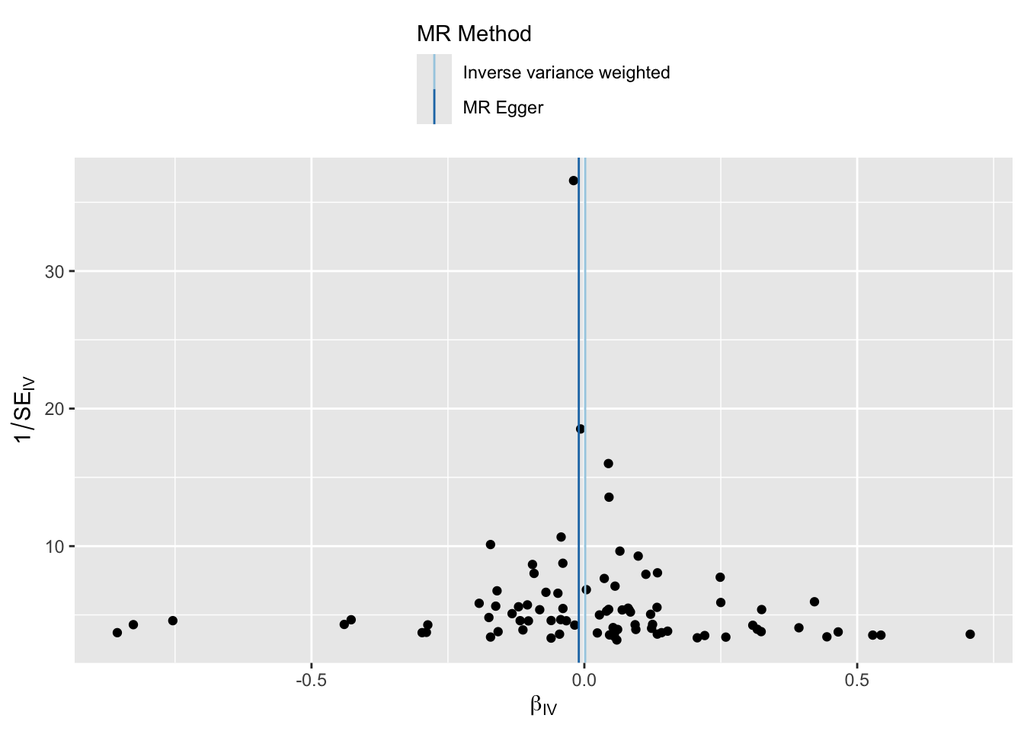

```r
p4_hdl_to_aam <- mr_funnel_plot(res_single_hdl_to_aam)
p4_hdl_to_aam[[1]]
```

```r
#Leoveone out analysis
res_loo_hdl_to_aam <- mr_leaveoneout(data_hdl_to_aam)
head(res_loo_hdl_to_aam)
```

```
                                exposure                          outcome
1 HDL cholesterol || id:ebi-a-GCST002223 Age at menarche || id:ieu-a-1095
2 HDL cholesterol || id:ebi-a-GCST002223 Age at menarche || id:ieu-a-1095
3 HDL cholesterol || id:ebi-a-GCST002223 Age at menarche || id:ieu-a-1095
4 HDL cholesterol || id:ebi-a-GCST002223 Age at menarche || id:ieu-a-1095
5 HDL cholesterol || id:ebi-a-GCST002223 Age at menarche || id:ieu-a-1095
6 HDL cholesterol || id:ebi-a-GCST002223 Age at menarche || id:ieu-a-1095
       id.exposure id.outcome samplesize        SNP             b         se
1 ebi-a-GCST002223 ieu-a-1095     182416 rs10019888  0.0008601150 0.01701328
2 ebi-a-GCST002223 ieu-a-1095     182416 rs10087900  0.0019057216 0.01706438
3 ebi-a-GCST002223 ieu-a-1095     182416 rs10282707  0.0033440817 0.01680166
4 ebi-a-GCST002223 ieu-a-1095     182416 rs10468017  0.0022017352 0.01773731
5 ebi-a-GCST002223 ieu-a-1095     182416  rs1047891  0.0013873322 0.01706741
6 ebi-a-GCST002223 ieu-a-1095     182416 rs10761771 -0.0005131254 0.01656692
          p
1 0.9596797
2 0.9110784
3 0.8422371
4 0.9012122
5 0.9352149
6 0.9752912
```

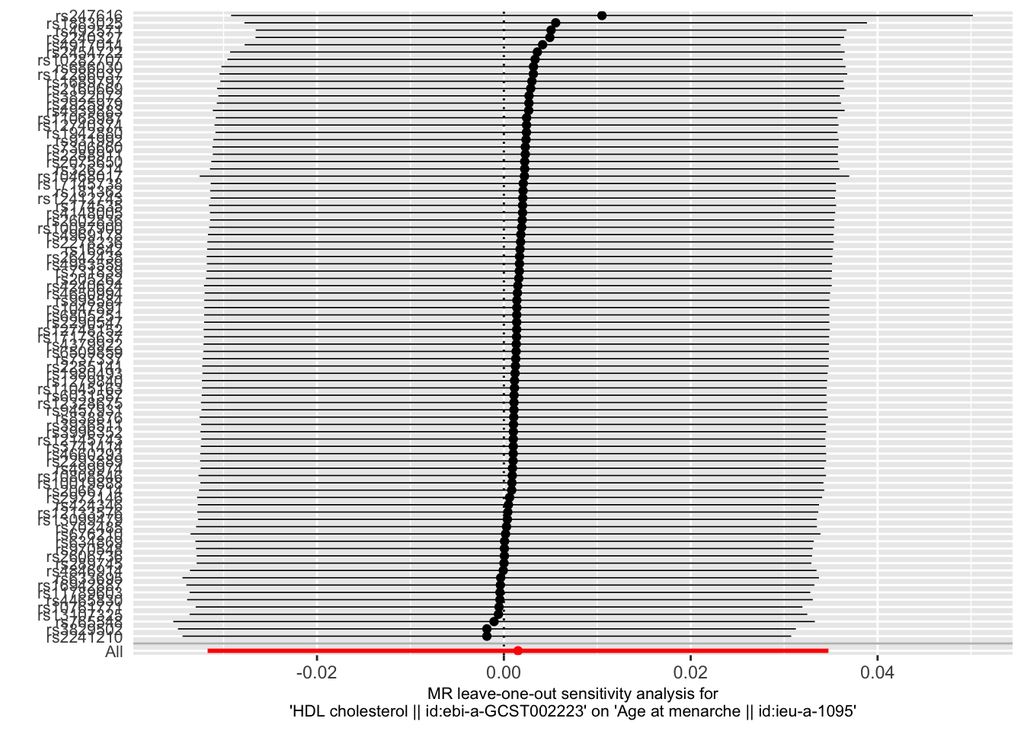

```r
p_loo_hdl_to_aam <- mr_leaveoneout_plot(res_loo_hdl_to_aam)
p_loo_hdl_to_aam[[1]]
```

```r
#steiger
out_hdl_to_aam <- directionality_test(data_hdl_to_aam)
```

```
r.exposure and/or r.outcome not present.
Calculating approximate SNP-exposure and/or SNP-outcome correlations, assuming all are quantitative traits. Please pre-calculate r.exposure and/or r.outcome using get_r_from_lor() for any binary traits
```

```r
out_hdl_to_aam
```

```
       id.exposure id.outcome                               exposure
1 ebi-a-GCST002223 ieu-a-1095 HDL cholesterol || id:ebi-a-GCST002223
                           outcome snp_r2.exposure snp_r2.outcome
1 Age at menarche || id:ieu-a-1095      0.09493388    0.000603294
  correct_causal_direction steiger_pval
1                     TRUE            0
```

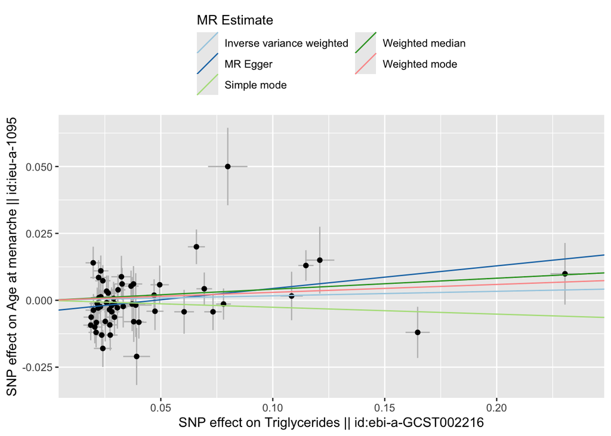

```r
#############################
###Visualization: TG to AAM
data_tg_to_aam <- harmonised_results_lipids_to_aam[["ebi-a-GCST002216"]]
#mr analysis
res_tg_to_aam  <- mr_results_lipids_to_aam[["ebi-a-GCST002216"]]

p1_tg_to_aam <- mr_scatter_plot(res_tg_to_aam, data_tg_to_aam)
p1_tg_to_aam[[1]]
```

```r
#heterogeneity
mr_heterogeneity(data_tg_to_aam)
```

```
       id.exposure id.outcome                          outcome
1 ebi-a-GCST002216 ieu-a-1095 Age at menarche || id:ieu-a-1095
2 ebi-a-GCST002216 ieu-a-1095 Age at menarche || id:ieu-a-1095
                              exposure                    method        Q Q_df
1 Triglycerides || id:ebi-a-GCST002216                  MR Egger 85.76877   53
2 Triglycerides || id:ebi-a-GCST002216 Inverse variance weighted 93.37045   54
       Q_pval
1 0.002927585
2 0.000707501
```

```r
#pleiotropy
mr_pleiotropy_test(data_tg_to_aam)
```

```
       id.exposure id.outcome                          outcome
1 ebi-a-GCST002216 ieu-a-1095 Age at menarche || id:ieu-a-1095
                              exposure egger_intercept          se       pval
1 Triglycerides || id:ebi-a-GCST002216    -0.004035065 0.001861754 0.03472185
```

```r
#single snp analysis
res_single_tg_to_aam <- mr_singlesnp(data_tg_to_aam)
head(res_single_tg_to_aam)
```

```
                              exposure                          outcome
1 Triglycerides || id:ebi-a-GCST002216 Age at menarche || id:ieu-a-1095
2 Triglycerides || id:ebi-a-GCST002216 Age at menarche || id:ieu-a-1095
3 Triglycerides || id:ebi-a-GCST002216 Age at menarche || id:ieu-a-1095
4 Triglycerides || id:ebi-a-GCST002216 Age at menarche || id:ieu-a-1095
5 Triglycerides || id:ebi-a-GCST002216 Age at menarche || id:ieu-a-1095
6 Triglycerides || id:ebi-a-GCST002216 Age at menarche || id:ieu-a-1095
       id.exposure id.outcome samplesize        SNP           b         se
1 ebi-a-GCST002216 ieu-a-1095     182416 rs10401969  0.12396694 0.10327521
2 ebi-a-GCST002216 ieu-a-1095     182416 rs10426094 -0.74688797 0.28757967
3 ebi-a-GCST002216 ieu-a-1095     182416 rs10440120 -0.09150327 0.25526863
4 ebi-a-GCST002216 ieu-a-1095     182416 rs10501321 -0.05555556 0.27517269
5 ebi-a-GCST002216 ieu-a-1095     182416 rs10790162  0.04295011 0.04996443
6 ebi-a-GCST002216 ieu-a-1095     182416 rs11057408 -0.03488372 0.23106512
            p
1 0.230001379
2 0.009400045
3 0.720000047
4 0.840000043
5 0.390001976
6 0.879999995
```

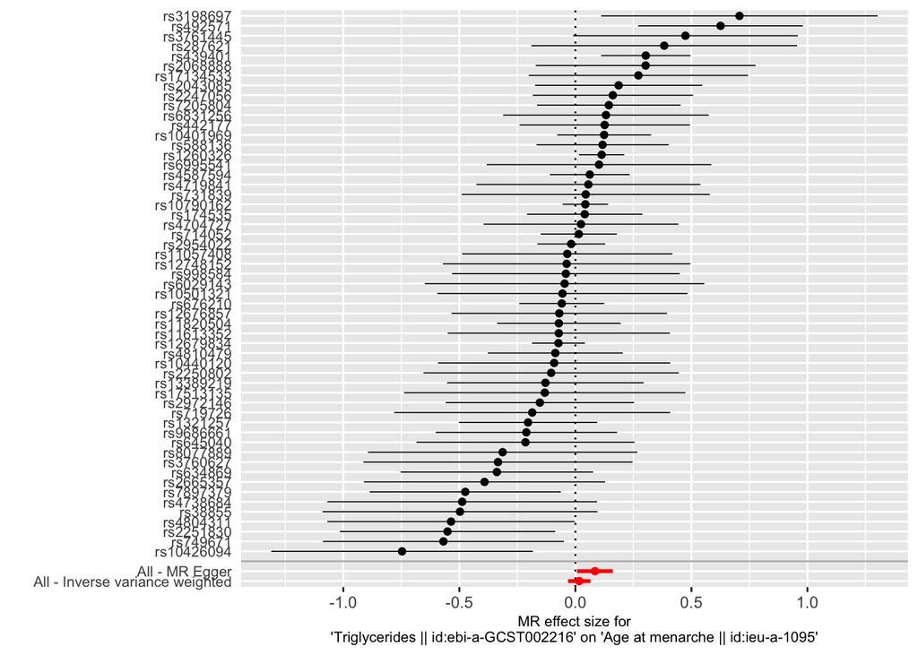

```r
p2_tg_to_aam <- mr_forest_plot(res_single_tg_to_aam)
p2_tg_to_aam[[1]]
```

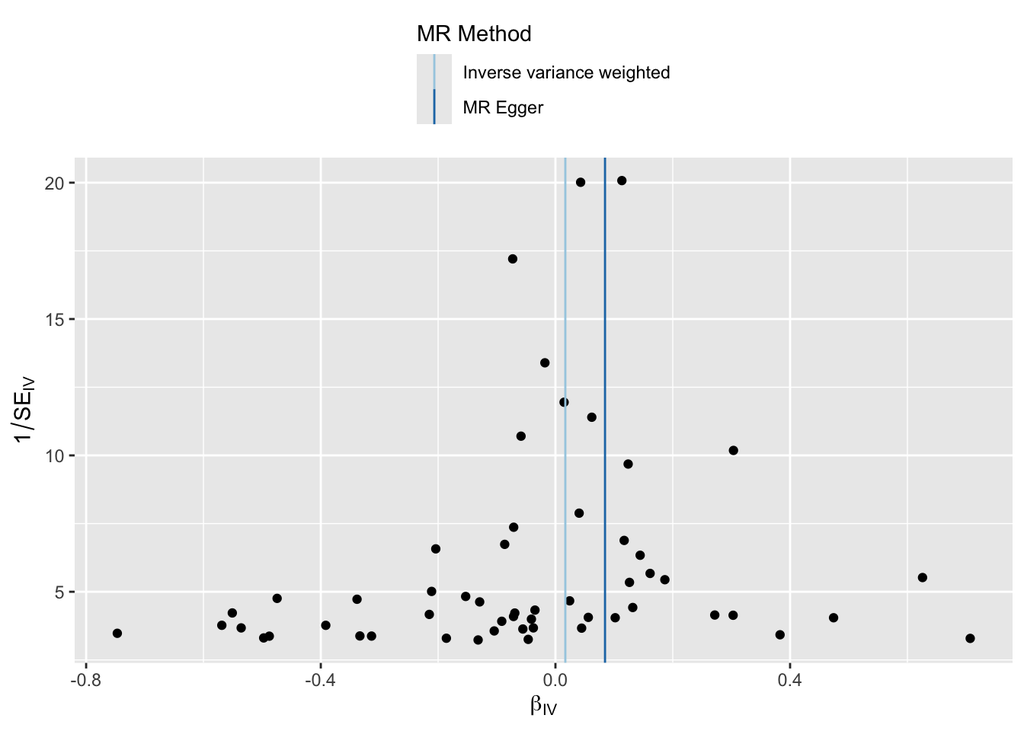

```r
p4_tg_to_aam <- mr_funnel_plot(res_single_tg_to_aam)
p4_tg_to_aam[[1]]
```

```r
#leaveoneout
res_loo_tg_to_aam <- mr_leaveoneout(data_tg_to_aam)
head(res_loo_tg_to_aam)
```

```
                              exposure                          outcome
1 Triglycerides || id:ebi-a-GCST002216 Age at menarche || id:ieu-a-1095
2 Triglycerides || id:ebi-a-GCST002216 Age at menarche || id:ieu-a-1095
3 Triglycerides || id:ebi-a-GCST002216 Age at menarche || id:ieu-a-1095
4 Triglycerides || id:ebi-a-GCST002216 Age at menarche || id:ieu-a-1095
5 Triglycerides || id:ebi-a-GCST002216 Age at menarche || id:ieu-a-1095
6 Triglycerides || id:ebi-a-GCST002216 Age at menarche || id:ieu-a-1095
       id.exposure id.outcome samplesize        SNP          b         se
1 ebi-a-GCST002216 ieu-a-1095     182416 rs10401969 0.01320874 0.02516169
2 ebi-a-GCST002216 ieu-a-1095     182416 rs10426094 0.02012300 0.02398030
3 ebi-a-GCST002216 ieu-a-1095     182416 rs10440120 0.01744916 0.02493528
4 ebi-a-GCST002216 ieu-a-1095     182416 rs10501321 0.01719902 0.02494077
5 ebi-a-GCST002216 ieu-a-1095     182416 rs10790162 0.01258277 0.02680994
6 ebi-a-GCST002216 ieu-a-1095     182416 rs11057408 0.01720421 0.02496770
          p
1 0.5996149
2 0.4013866
3 0.4840660
4 0.4904491
5 0.6388323
6 0.4907863
```

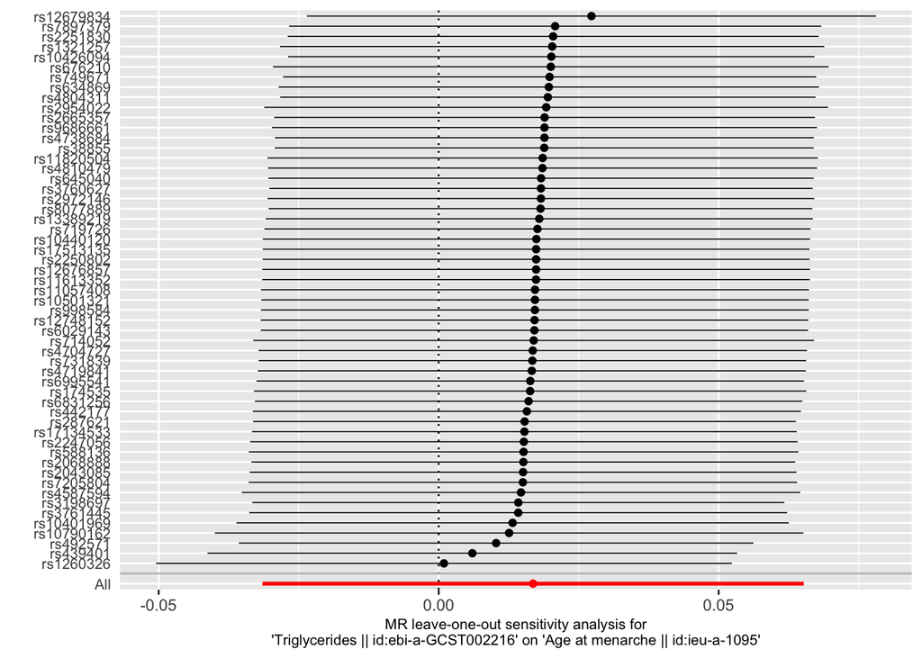

```r
p_loo_tg_to_aam <- mr_leaveoneout_plot(res_loo_tg_to_aam)
p_loo_tg_to_aam[[1]]
```

```r
#steiger
out_tg_to_aam <- directionality_test(data_tg_to_aam)
```

```
r.exposure and/or r.outcome not present.
Calculating approximate SNP-exposure and/or SNP-outcome correlations, assuming all are quantitative traits. Please pre-calculate r.exposure and/or r.outcome using get_r_from_lor() for any binary traits
```

```r
out_tg_to_aam
```

```
       id.exposure id.outcome                             exposure
1 ebi-a-GCST002216 ieu-a-1095 Triglycerides || id:ebi-a-GCST002216
                           outcome snp_r2.exposure snp_r2.outcome
1 Age at menarche || id:ieu-a-1095      0.08174223   0.0005162857
  correct_causal_direction steiger_pval
1                     TRUE            0
```

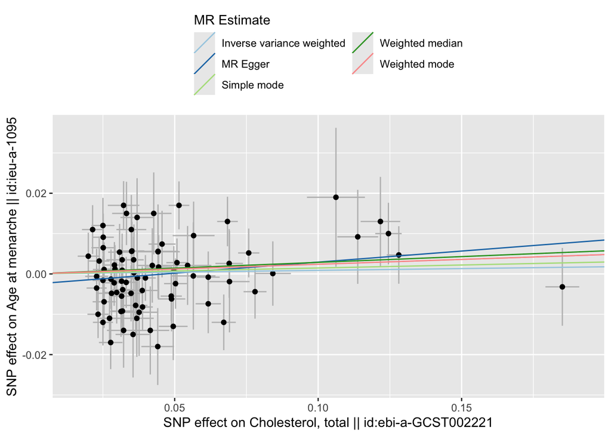

```r
#############################
###Visualization of reverse: TC to AAM
data_tc_to_aam <- harmonised_results_lipids_to_aam[["ebi-a-GCST002221"]]
res_tc_to_aam  <- mr_results_lipids_to_aam[["ebi-a-GCST002221"]]

p1_tc_to_aam <- mr_scatter_plot(res_tc_to_aam, data_tc_to_aam)
p1_tc_to_aam[[1]]
```

```r
#heterogeneity
mr_heterogeneity(data_tc_to_aam)
```

```
       id.exposure id.outcome                          outcome
1 ebi-a-GCST002221 ieu-a-1095 Age at menarche || id:ieu-a-1095
2 ebi-a-GCST002221 ieu-a-1095 Age at menarche || id:ieu-a-1095
                                   exposure                    method        Q
1 Cholesterol, total || id:ebi-a-GCST002221                  MR Egger 100.5692
2 Cholesterol, total || id:ebi-a-GCST002221 Inverse variance weighted 103.2275
  Q_df     Q_pval
1   79 0.05126621
2   80 0.04134778
```

```r
#pleiotropy
mr_pleiotropy_test(data_tc_to_aam)
```

```
       id.exposure id.outcome                          outcome
1 ebi-a-GCST002221 ieu-a-1095 Age at menarche || id:ieu-a-1095
                                   exposure egger_intercept          se
1 Cholesterol, total || id:ebi-a-GCST002221    -0.002554082 0.001767467
       pval
1 0.1523984
```

```r
#single snp analysis
res_single_tc_to_aam <- mr_singlesnp(data_tc_to_aam)
head(res_single_tc_to_aam)
```

```
                                   exposure                          outcome
1 Cholesterol, total || id:ebi-a-GCST002221 Age at menarche || id:ieu-a-1095
2 Cholesterol, total || id:ebi-a-GCST002221 Age at menarche || id:ieu-a-1095
3 Cholesterol, total || id:ebi-a-GCST002221 Age at menarche || id:ieu-a-1095
4 Cholesterol, total || id:ebi-a-GCST002221 Age at menarche || id:ieu-a-1095
5 Cholesterol, total || id:ebi-a-GCST002221 Age at menarche || id:ieu-a-1095
6 Cholesterol, total || id:ebi-a-GCST002221 Age at menarche || id:ieu-a-1095
       id.exposure id.outcome samplesize        SNP           b        se
1 ebi-a-GCST002221 ieu-a-1095     182416 rs10088180 -0.02631579 0.2995711
2 ebi-a-GCST002221 ieu-a-1095     182416 rs10468017 -0.01296596 0.1031818
3 ebi-a-GCST002221 ieu-a-1095     182416 rs10490626 -0.33734940 0.2632361
4 ebi-a-GCST002221 ieu-a-1095     182416 rs10750219 -0.17142857 0.2036886
5 ebi-a-GCST002221 ieu-a-1095     182416 rs10773003  0.37940379 0.2635607
6 ebi-a-GCST002221 ieu-a-1095     182416 rs10832962 -0.17460317 0.2119244
          p
1 0.9299999
2 0.9000000
3 0.2000017
4 0.4000002
5 0.1500001
6 0.4100001
```

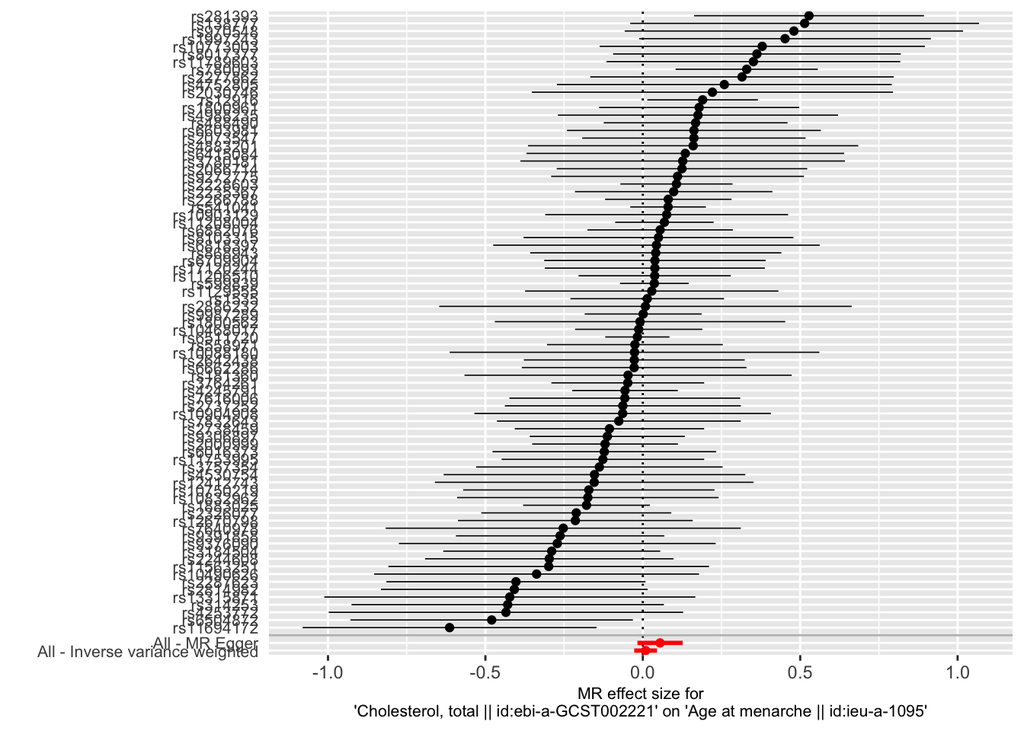

```r
p2_tc_to_aam <- mr_forest_plot(res_single_tc_to_aam)
p2_tc_to_aam[[1]]
```

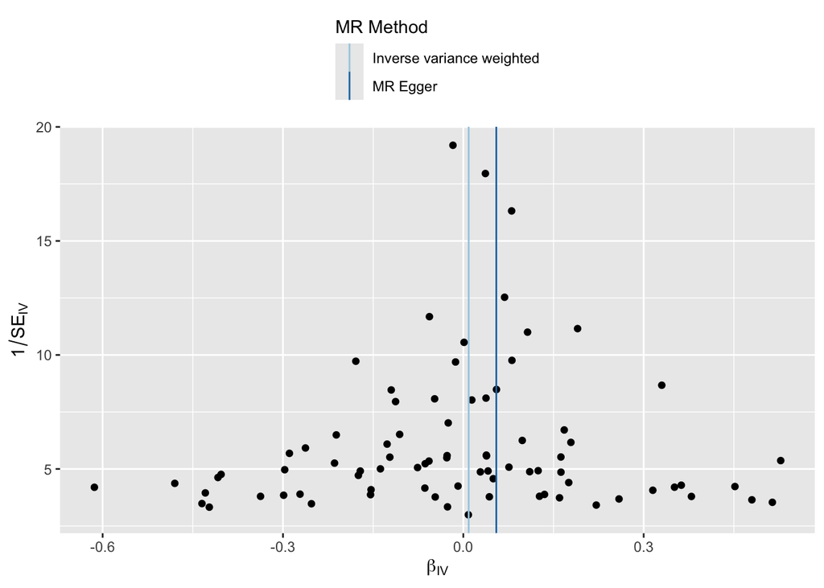

```r
p4_tc_to_aam <- mr_funnel_plot(res_single_tc_to_aam)
p4_tc_to_aam[[1]]
```

```r
#leoveoeout analysis
res_loo_tc_to_aam <- mr_leaveoneout(data_tc_to_aam)
head(res_loo_tc_to_aam)
```

```
                                   exposure                          outcome
1 Cholesterol, total || id:ebi-a-GCST002221 Age at menarche || id:ieu-a-1095
2 Cholesterol, total || id:ebi-a-GCST002221 Age at menarche || id:ieu-a-1095
3 Cholesterol, total || id:ebi-a-GCST002221 Age at menarche || id:ieu-a-1095
4 Cholesterol, total || id:ebi-a-GCST002221 Age at menarche || id:ieu-a-1095
5 Cholesterol, total || id:ebi-a-GCST002221 Age at menarche || id:ieu-a-1095
6 Cholesterol, total || id:ebi-a-GCST002221 Age at menarche || id:ieu-a-1095
       id.exposure id.outcome samplesize        SNP           b         se
1 ebi-a-GCST002221 ieu-a-1095     182416 rs10088180 0.008978611 0.01855764
2 ebi-a-GCST002221 ieu-a-1095     182416 rs10468017 0.009428072 0.01876057
3 ebi-a-GCST002221 ieu-a-1095     182416 rs10490626 0.010193440 0.01841010
4 ebi-a-GCST002221 ieu-a-1095     182416 rs10750219 0.010024705 0.01851952
5 ebi-a-GCST002221 ieu-a-1095     182416 rs10773003 0.007468008 0.01838756
6 ebi-a-GCST002221 ieu-a-1095     182416 rs10832962 0.009955272 0.01851815
          p
1 0.6285115
2 0.6152827
3 0.5797928
4 0.5882975
5 0.6846364
6 0.5908564
```

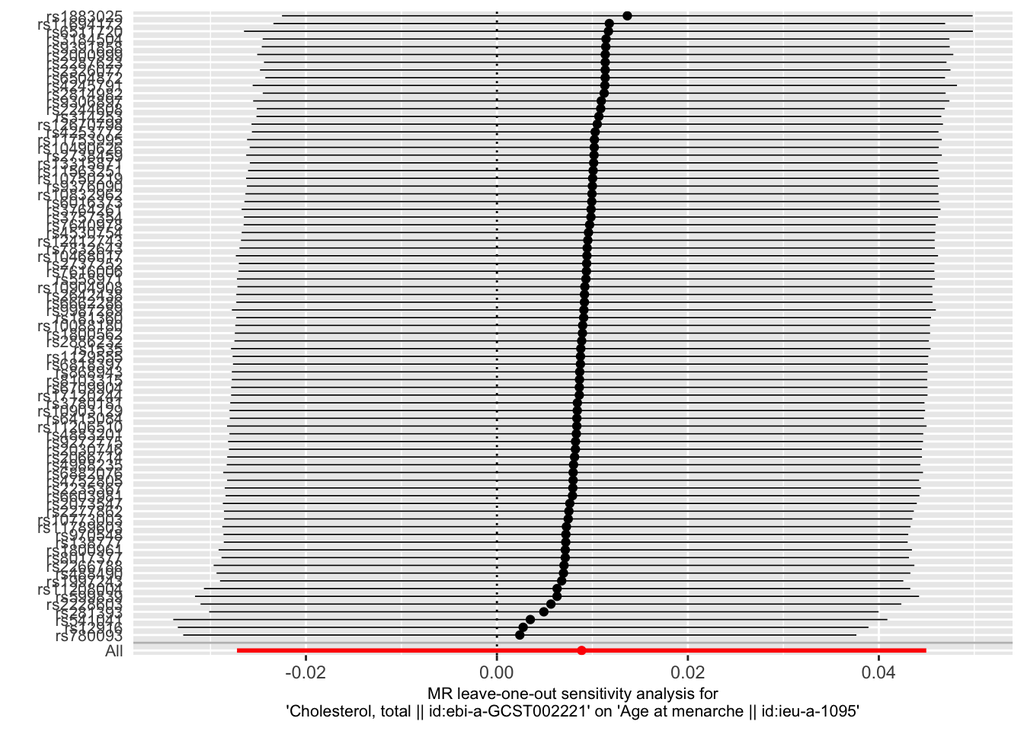

```r
p_loo_tc_to_aam <- mr_leaveoneout_plot(res_loo_tc_to_aam)
p_loo_tc_to_aam[[1]]
```

```r
#steiger
out_tc_to_aam <- directionality_test(data_tc_to_aam)
```

```
r.exposure and/or r.outcome not present.
Calculating approximate SNP-exposure and/or SNP-outcome correlations, assuming all are quantitative traits. Please pre-calculate r.exposure and/or r.outcome using get_r_from_lor() for any binary traits
```

```r
out_tc_to_aam
```

```
       id.exposure id.outcome                                  exposure
1 ebi-a-GCST002221 ieu-a-1095 Cholesterol, total || id:ebi-a-GCST002221
                           outcome snp_r2.exposure snp_r2.outcome
1 Age at menarche || id:ieu-a-1095       0.1035706   0.0005798003
  correct_causal_direction steiger_pval
1                     TRUE            0
```

### 4.7.1 Results for Reverse MR (Lipids → AAM)

#### 4.7.1.1 LDL cholesterol (LDL → AAM)

| Method | β (Effect) | SE | p-value | Interpretation |
| --- | --- | --- | --- | --- |
| MR-Egger | 0.0403 | 0.0330 | 0.2275 | Not significant |
| Weighted median | 0.0020 | 0.0275 | 0.9416 | Not significant |
| IVW | -0.0120 | 0.0185 | 0.5146 | Not significant |
| Simple mode | -0.0132 | 0.0491 | 0.7881 | Not significant |
| Weighted mode | 0.0019 | 0.0254 | 0.9410 | Not significant |

As seen on the table above and MR scatter plot, the estimates lie close to 0 and are insignificant, suggesting no causal effect of LDL levels on AAM .

**Sensitivity analyses**

- Heterogeneity -> Insignificant heterogeneity was observed ( MR Egger and IVW Qp-values 0.1459 and 0.2080 respectively), indicating consistent SNP effects and suggesting no possible pleiotropic effects.
- MR-Egger pleiotropy test -> The MR egger intercept was not significant (p-value 0.67), indicating no evidence of directional pleiotropy.
- Steiger directionality test -> p = 0, significant, causal direction is correct, LDL to AAM.
- Single SNP analysis (and the forest plot) -> The SNPs show insignificant (p-values >0.05 and CI crossing 0). The effect sizes go in both positive and negative directions. MR-Egger and IVW summary estimates overlap but also cross 0, thus not significant, indicating no specific outliers.
  - Funnel plot: The SNPs show symmetrical distribution, indicating no directional horizontal pleiotropy.
- Leave-one-out analysis -> All p-values remained insignificant, suggesting no SNP is driving the observed effect.
  - LOO plot -> Each dot represents the IVW estimate after removing one SNP at a time. All the SNPs CI cross 0 and show have insignificant results, indicating no SNP shifts/drives the effect.

Conclusion: LDL levels have no causal effect on AAM.

#### 4.7.1.2 HDL cholesterol (HDL → AAM)

| Method | β (Effect) | SE | p-value | Interpretation |
| --- | --- | --- | --- | --- |
| MR-Egger | -0.0102 | 0.0279 | 0.7159 | Not significant |
| Weighted median | -0.0183 | 0.0246 | 0.4559 | Not significant |
| IVW | 0.0015 | 0.0170 | 0.9287 | Not significant |
| Simple mode | 0.0545 | 0.0472 | 0.2518 | Not significant |
| Weighted mode | -0.0090 | 0.0212 | 0.6722 | Not significant |

As seen on the table above and MR scatter plot, the estimates lie close to 0 with some showing negative and positive effect sizes but the P-values are insignificant, suggesting no causal effect of HDL levels on AAM.

**Sensitivity analyses**

- Heterogeneity -> Significant heterogeneity was observed ( MR Egger and IVW Qp-values 0.0315and 0.0352 respectively), indicating inconsistent SNP effects and suggesting possible pleiotropic effects.
- MR-Egger pleiotropy test -> The MR egger intercept was not significant (p-value 0.5977), indicating no evidence of directional pleiotropy.
- Steiger directionality test -> p = 0, significant, causal direction is correct, HDL to AAM.
- Single SNP analysis (and the forest plots) -> The SNPs show insignificant (p-values >0.05 and CI crossing 0). MR-Egger and IVW summary estimates overlap and close to 0, thus not significant, indicating no specific outliers.
  - Funnel plot: The SNPs show symmetrical distribution, indicating no directional horizontal pleiotropy.
- Leave-one-out analysis -> All p-values remained insignificant, suggesting no SNP is driving the observed effect.
- LOO plot -> Each dot represents the IVW estimate after removing one SNP at a time. All the SNPs CI cross 0 and show have insignificant results, indicating no SNP shifts/drives the effect.

Conclusion: HDL levels have no causal effect on AAM.

#### 4.7.1.3 Triglycerides (TG → AAM)

| Method | β (Effect) | SE | p-value | Interpretation |
| --- | --- | --- | --- | --- |
| MR-Egger | 0.0845 | 0.0393 | **0.0360** | **Significant** |
| Weighted median | 0.0414 | 0.0318 | 0.1930 | Not significant |
| IVW | 0.0169 | 0.0247 | 0.4942 | Not significant |
| Simple mode | -0.0259 | 0.0537 | 0.6322 | Not significant |
| Weighted mode | 0.0297 | 0.0301 | 0.3291 | Not significant |

Conclusion: TG levels have no causal effect on AAM.

#### 4.7.1.4 **Total cholesterol (TC** → AAM)

| Method | β (Effect) | SE | p-value | Interpretation |
| --- | --- | --- | --- | --- |
| MR-Egger | 0.0548 | 0.0367 | 0.1390 | Not significant |
| Weighted median | 0.0287 | 0.0260 | 0.2694 | Not significant |
| IVW | 0.0089 | 0.0184 | 0.6298 | Not significant |
| Simple mode | 0.0148 | 0.0511 | 0.7734 | Not significant |
| Weighted mode | 0.0241 | 0.0308 | 0.4353 | Not significant |

As seen on the table above and MR scatter plot, the estimates lie close to 0 with some most showing positive effect sizes but the p-values are insignificant, suggesting no causal effect of TC levels on AAM.

Conclusion: TC levels have no causal effect on AAM.

### 4.7.2 **Reverse Multivariable MR (MVMR)**

Direction: Lipids + BMI → AAM  
Exposures: HDL, LDL, TG and TC , Body Mass Index  
Outcome: Age at Menarche  
Research Question: Do lipid levels influence age at menarche independent of BMI? and does BMI affect the each lipid level independent of AAM.

```r
######################################################
# Reverse Multivariable MR: Lipids + BMI → AAM
######################################################

# 1. Exposures = Lipids + BMI
exp_mvmr_lipids_to_aam_bmi <- mv_extract_exposures(
  id_exposure = c(
    lipids,   # lipids
    "ieu-a-2" # BMI
  ),
  clump_r2 = 0.001,
  clump_kb = 10000,
  pop = "EUR"
)
```

```
Please look at vignettes for options on running this locally if you need to run many instances of this command.
```

```
Clumping 1, 330 variants, using EUR population reference
```

```
Removing 144 of 330 variants due to LD with other variants or absence from LD reference panel
```

```
Extracting data for 186 SNP(s) from 5 GWAS(s)
```

```
Querying id chunk 1 of 1
```

[output not shown]

[output not shown]

[output not shown]

[output not shown]

[output not shown]

[output not shown]

[output not shown]

[output not shown]

[output not shown]

[output not shown]

[output not shown]

[output not shown]

[output not shown]

[output not shown]

[output not shown]

[output not shown]

```
Finding proxies for 1 SNPs in outcome ebi-a-GCST002222
```

```
Extracting data for 1 SNP(s) from 1 GWAS(s)
```

```
Querying id chunk 1 of 1
```

```
Querying variant chunk 1 of 1
```

```
Finding proxies for 1 SNPs in outcome ebi-a-GCST002223
```

```
Extracting data for 1 SNP(s) from 1 GWAS(s)
```

```
Querying id chunk 1 of 1
```

```
Querying variant chunk 1 of 1
```

```
Finding proxies for 2 SNPs in outcome ebi-a-GCST002216
```

```
Extracting data for 2 SNP(s) from 1 GWAS(s)
```

```
Querying id chunk 1 of 1
```

```
Querying variant chunk 1 of 1
```

```
Finding proxies for 1 SNPs in outcome ebi-a-GCST002221
```

```
Extracting data for 1 SNP(s) from 1 GWAS(s)
```

```
Querying id chunk 1 of 1
```

```
Querying variant chunk 1 of 1
```

```
Finding proxies for 2 SNPs in outcome ieu-a-2
```

```
Extracting data for 2 SNP(s) from 1 GWAS(s)
```

```
Querying id chunk 1 of 1
```

```
Querying variant chunk 1 of 1
```

```
Harmonising LDL cholesterol || id:ebi-a-GCST002222 (ebi-a-GCST002222) and Triglycerides || id:ebi-a-GCST002216 (ebi-a-GCST002216)
```

```
Removing the following SNPs for being palindromic with intermediate allele frequencies:
rs14810, rs17001654, rs3758348, rs378479, rs7534572, rs9491696, rs9914578
```

```
Harmonising LDL cholesterol || id:ebi-a-GCST002222 (ebi-a-GCST002222) and Cholesterol, total || id:ebi-a-GCST002221 (ebi-a-GCST002221)
```

```
Removing the following SNPs for being palindromic with intermediate allele frequencies:
rs14810, rs17001654, rs3758348, rs378479, rs7534572, rs9491696, rs9914578
```

```
Harmonising LDL cholesterol || id:ebi-a-GCST002222 (ebi-a-GCST002222) and HDL cholesterol || id:ebi-a-GCST002223 (ebi-a-GCST002223)
```

```
Removing the following SNPs for being palindromic with intermediate allele frequencies:
rs14810, rs17001654, rs3758348, rs378479, rs7534572, rs9491696, rs9914578
```

```
Harmonising LDL cholesterol || id:ebi-a-GCST002222 (ebi-a-GCST002222) and Body mass index || id:ieu-a-2 (ieu-a-2)
```

```
Removing the following SNPs for being palindromic with intermediate allele frequencies:
rs14810, rs17001654, rs3758348, rs378479, rs9491696, rs9914578
```

```r
# 2. Outcome = AAM
out_mvmr_lipids_to_aam_bmi <- extract_outcome_data(
  snps     = exp_mvmr_lipids_to_aam_bmi$SNP,
  outcomes = "ieu-a-1095"
)
```

```
Extracting data for 176 SNP(s) from 1 GWAS(s)
```

```
Querying id chunk 1 of 1
```

```
Querying variant chunk 1 of 3
```

```
Querying variant chunk 2 of 3
```

```
Querying variant chunk 3 of 3
```

```
Finding proxies for 5 SNPs in outcome ieu-a-1095
```

```
Extracting data for 5 SNP(s) from 1 GWAS(s)
```

```
Querying id chunk 1 of 1
```

```
Querying variant chunk 1 of 1
```

```r
# 3. Harmonise
mvmr_dat_lipids_to_aam_bmi <- mv_harmonise_data(
  exposure_dat = exp_mvmr_lipids_to_aam_bmi,
  outcome_dat  = out_mvmr_lipids_to_aam_bmi
)
```

```
Harmonising LDL cholesterol || id:ebi-a-GCST002222 (ebi-a-GCST002222) and Age at menarche || id:ieu-a-1095 (ieu-a-1095)
```

```r
# 4. Run multivariable MR
res_mvmr_lipids_to_aam_bmi <- mv_multiple(mvmr_dat_lipids_to_aam_bmi)
res_mvmr_lipids_to_aam_bmi$result
```

```
       id.exposure                                  exposure id.outcome
1 ebi-a-GCST002216      Triglycerides || id:ebi-a-GCST002216 ieu-a-1095
2 ebi-a-GCST002221 Cholesterol, total || id:ebi-a-GCST002221 ieu-a-1095
3 ebi-a-GCST002222    LDL cholesterol || id:ebi-a-GCST002222 ieu-a-1095
4 ebi-a-GCST002223    HDL cholesterol || id:ebi-a-GCST002223 ieu-a-1095
5          ieu-a-2             Body mass index || id:ieu-a-2 ieu-a-1095
                           outcome nsnp           b         se         pval
1 Age at menarche || id:ieu-a-1095   35  0.01878774 0.10761983 8.614135e-01
2 Age at menarche || id:ieu-a-1095   67 -0.05392406 0.29254452 8.537564e-01
3 Age at menarche || id:ieu-a-1095   53  0.02567207 0.25491217 9.197811e-01
4 Age at menarche || id:ieu-a-1095   69  0.01705047 0.12865837 8.945690e-01
5 Age at menarche || id:ieu-a-1095   51 -0.54435966 0.04772129 3.855368e-30
```

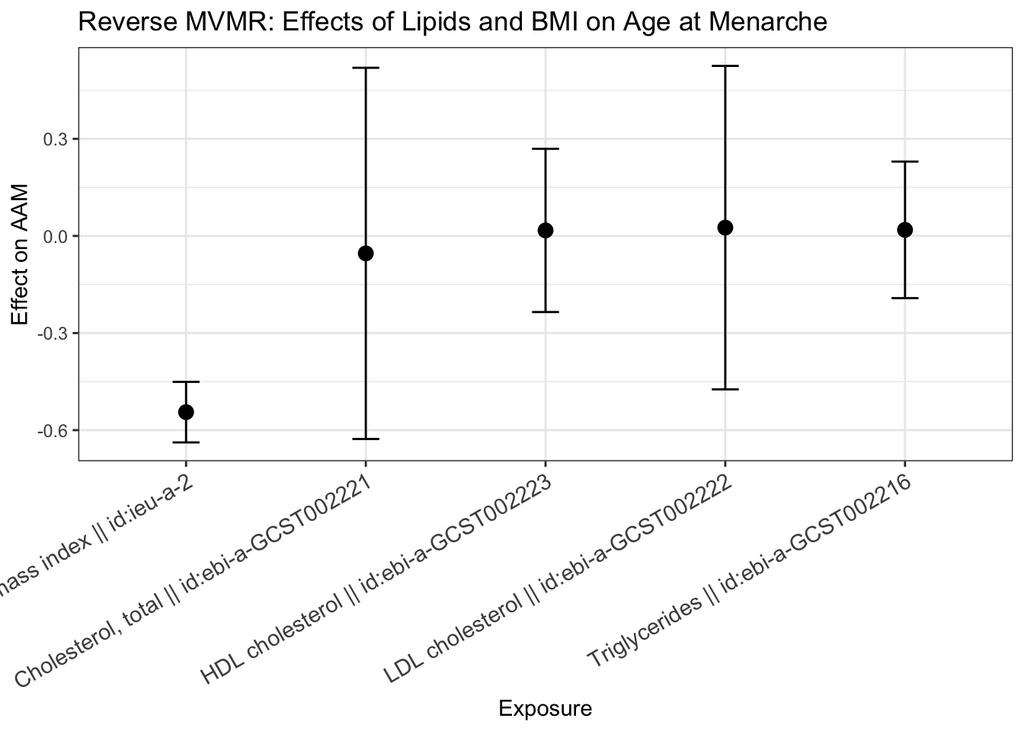

```r
#Plot reverse MVMR

ggplot(res_mvmr_lipids_to_aam_bmi$result, aes(x = exposure, y = b)) +
  geom_point(size = 3) +
  geom_errorbar(
    aes(ymin = b - 1.96 * se, ymax = b + 1.96 * se),
    width = 0.15
  ) +
  theme_bw() +
  theme(
    axis.text.x = element_text(angle = 30, hjust = 1, size = 11)
  ) +
  labs(
    title = "Reverse MVMR: Effects of Lipids and BMI on Age at Menarche",
    x = "Exposure",
    y = "Effect on AAM"
  )
```

#### 4.7.2.1 Results for Reverse MVMR (Lipids + BMI → AAM)

| Exposure | SNPs | β | SE | p-value |  |
| --- | --- | --- | --- | --- | --- |
| Triglycerides | 35 | 0.0188 | 0.1076 | 0.8614 | Not significant |
| Total Cholesterol | 67 | -0.0539 | 0.2925 | 0.8538 | Not significant |
| LDL Cholesterol | 53 | 0.0257 | 0.2549 | 0.9198 | Not significant |
| HDL Cholesterol | 69 | 0.0171 | 0.1287 | 0.8946 | Not significant |
| Body Mass Index (BMI) | 51 | -0.5444 | 0.0477 | 3.86 × 10⁻³⁰ | Highly significant |

Only BMI showed significant causal effects on AAM, suggesting higher BMI leads to earlier age at menarche. Higher BMI, early puberty.

# 5 **Age at Natural Menopause**

## 5.1 Age at natural menopause and Type 2 Diabetes

## 5.2 Forward MR

Direction: ANM → T2D Exposure: ANM Outcome: Type 2 Diabetes Research Question: Does ANM causally influence T2D risk?

```r
###################################################
# Forward MR: ANM -> T2D
##################################################

# Obtain the ANM exposure dataset from OpenGWAS
exposure_anm <- extract_instruments("ieu-a-1004")  #age at natural menopause

# Clumping
clumped_exp_anm <- clump_data(
  exposure_anm,
  clump_r2 = 0.001,
  clump_kb = 10000,
  pop = "EUR"
)
```

```
Please look at vignettes for options on running this locally if you need to run many instances of this command.
```

```
Clumping ieu-a-1004, 43 variants, using EUR population reference
```

```
Removing 2 of 43 variants due to LD with other variants or absence from LD reference panel
```

```r
### F statistic
clumped_exp_anm$F_statistic <- (clumped_exp_anm$beta.exposure^2) /
                               (clumped_exp_anm$se.exposure^2)
summary(clumped_exp_anm$F_statistic)
```

```
   Min. 1st Qu.  Median    Mean 3rd Qu.    Max.
  28.44   42.25   56.25   80.95   81.00  484.00
```

```r
# Outcome = T2D
outcome_anm_T2D <- extract_outcome_data(
  snps     = clumped_exp_anm$SNP,
  outcomes = "ebi-a-GCST005047"   # Morris T2D
)
```

```
Extracting data for 41 SNP(s) from 1 GWAS(s)
```

```
Querying id chunk 1 of 1
```

```
Querying variant chunk 1 of 1
```

```r
# Harmonise
harmonized_data_anm_T2D <- harmonise_data(
  clumped_exp_anm,
  outcome_anm_T2D,
  action = 1
)
```

```
Harmonising Age at menopause || id:ieu-a-1004 (ieu-a-1004) and Type 2 diabetes || id:ebi-a-GCST005047 (ebi-a-GCST005047)
```

```r
head(harmonized_data_anm_T2D)
```

```
         SNP effect_allele.exposure other_allele.exposure effect_allele.outcome
1  rs1046089                      A                     G                     A
2 rs10813912                      G                     A                     G
3 rs10905065                      A                     G                     A
4 rs10937153                      A                     G                     A
5 rs11031002                      A                     T                     A
6 rs11647580                      C                     G                     C
  other_allele.outcome beta.exposure beta.outcome eaf.exposure eaf.outcome
1                    G         -0.22   0.01980260         0.32          NA
2                    A          0.12   0.00995033         0.53          NA
3                    G         -0.11  -0.00995033         0.61          NA
4                    G          0.14  -0.02955880         0.23          NA
5                    T          0.22  -0.02955880         0.09          NA
6                    G         -0.16  -0.01980260         0.50          NA
  remove palindromic ambiguous       id.outcome chr       pos se.outcome
```

[output cut: 48 more lines]

```r
# Run MR
res_anm_T2D <- mr(harmonized_data_anm_T2D)
```

```
Analysing 'ieu-a-1004' on 'ebi-a-GCST005047'
```

```r
head(res_anm_T2D)
```

```
  id.exposure       id.outcome                                outcome
1  ieu-a-1004 ebi-a-GCST005047 Type 2 diabetes || id:ebi-a-GCST005047
2  ieu-a-1004 ebi-a-GCST005047 Type 2 diabetes || id:ebi-a-GCST005047
3  ieu-a-1004 ebi-a-GCST005047 Type 2 diabetes || id:ebi-a-GCST005047
4  ieu-a-1004 ebi-a-GCST005047 Type 2 diabetes || id:ebi-a-GCST005047
5  ieu-a-1004 ebi-a-GCST005047 Type 2 diabetes || id:ebi-a-GCST005047
                           exposure                    method nsnp           b
1 Age at menopause || id:ieu-a-1004                  MR Egger   41 -0.08271675
2 Age at menopause || id:ieu-a-1004           Weighted median   41 -0.04710971
3 Age at menopause || id:ieu-a-1004 Inverse variance weighted   41 -0.01828337
4 Age at menopause || id:ieu-a-1004               Simple mode   41 -0.06241617
5 Age at menopause || id:ieu-a-1004             Weighted mode   41 -0.06241617
          se        pval
1 0.04782130 0.091591318
2 0.02022908 0.019869067
3 0.01879502 0.330664023
4 0.04075453 0.133513588
5 0.02189731 0.006871403
```

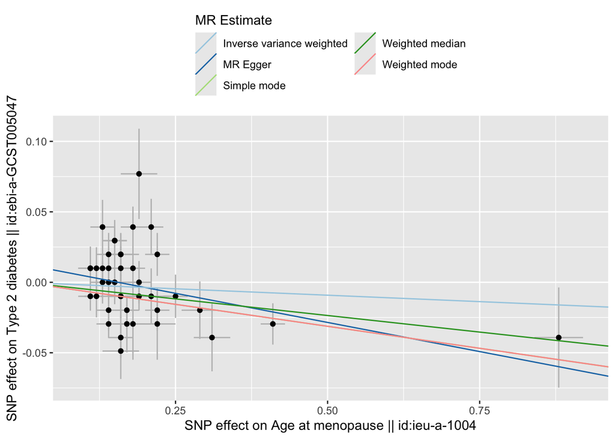

```r
# Scatter plot
p1_res_anm_T2D <- mr_scatter_plot(res_anm_T2D, harmonized_data_anm_T2D)
p1_res_anm_T2D[[1]]
```

```r
# Heterogeneity
mr_heterogeneity(harmonized_data_anm_T2D)
```

```
  id.exposure       id.outcome                                outcome
1  ieu-a-1004 ebi-a-GCST005047 Type 2 diabetes || id:ebi-a-GCST005047
2  ieu-a-1004 ebi-a-GCST005047 Type 2 diabetes || id:ebi-a-GCST005047
                           exposure                    method        Q Q_df
1 Age at menopause || id:ieu-a-1004                  MR Egger 85.13433   39
2 Age at menopause || id:ieu-a-1004 Inverse variance weighted 89.79774   40
        Q_pval
1 2.779106e-05
2 1.086847e-05
```

```r
# Pleiotropy
mr_pleiotropy_test(harmonized_data_anm_T2D)
```

```
  id.exposure       id.outcome                                outcome
1  ieu-a-1004 ebi-a-GCST005047 Type 2 diabetes || id:ebi-a-GCST005047
                           exposure egger_intercept          se      pval
1 Age at menopause || id:ieu-a-1004      0.01288234 0.008813793 0.1518591
```

```r
# Single SNP MR
res_single_anm_T2D <- mr_singlesnp(harmonized_data_anm_T2D)
head(res_single_anm_T2D)
```

```
                           exposure                                outcome
1 Age at menopause || id:ieu-a-1004 Type 2 diabetes || id:ebi-a-GCST005047
2 Age at menopause || id:ieu-a-1004 Type 2 diabetes || id:ebi-a-GCST005047
3 Age at menopause || id:ieu-a-1004 Type 2 diabetes || id:ebi-a-GCST005047
4 Age at menopause || id:ieu-a-1004 Type 2 diabetes || id:ebi-a-GCST005047
5 Age at menopause || id:ieu-a-1004 Type 2 diabetes || id:ebi-a-GCST005047
6 Age at menopause || id:ieu-a-1004 Type 2 diabetes || id:ebi-a-GCST005047
  id.exposure       id.outcome samplesize        SNP           b         se
1  ieu-a-1004 ebi-a-GCST005047      12171  rs1046089 -0.09001182 0.06722545
2  ieu-a-1004 ebi-a-GCST005047      12171 rs10813912  0.08291942 0.12444917
3  ieu-a-1004 ebi-a-GCST005047      12171 rs10905065  0.09045755 0.13985636
4  ieu-a-1004 ebi-a-GCST005047      12171 rs10937153 -0.21113429 0.07145929
5  ieu-a-1004 ebi-a-GCST005047      12171 rs11031002 -0.13435818 0.11540227
6  ieu-a-1004 ebi-a-GCST005047      12171 rs11647580  0.12376625 0.09519437
           p
1 0.18058552
2 0.50522482
3 0.51776857
4 0.00313065
5 0.24431890
6 0.19355214
```

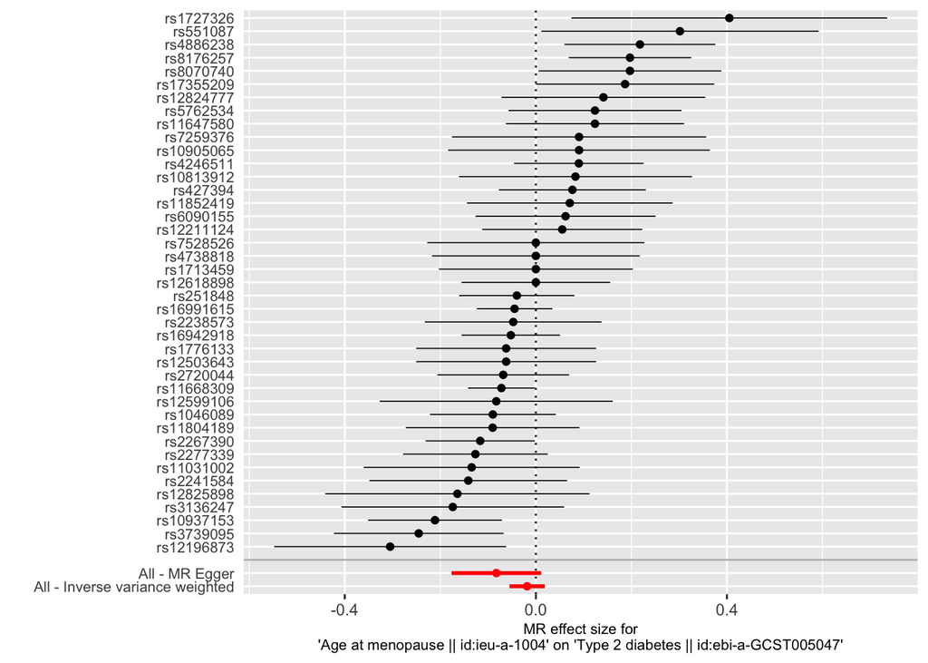

```r
# Forest plot
p2_res_single_anm_T2D <- mr_forest_plot(res_single_anm_T2D)
p2_res_single_anm_T2D[[1]]
```

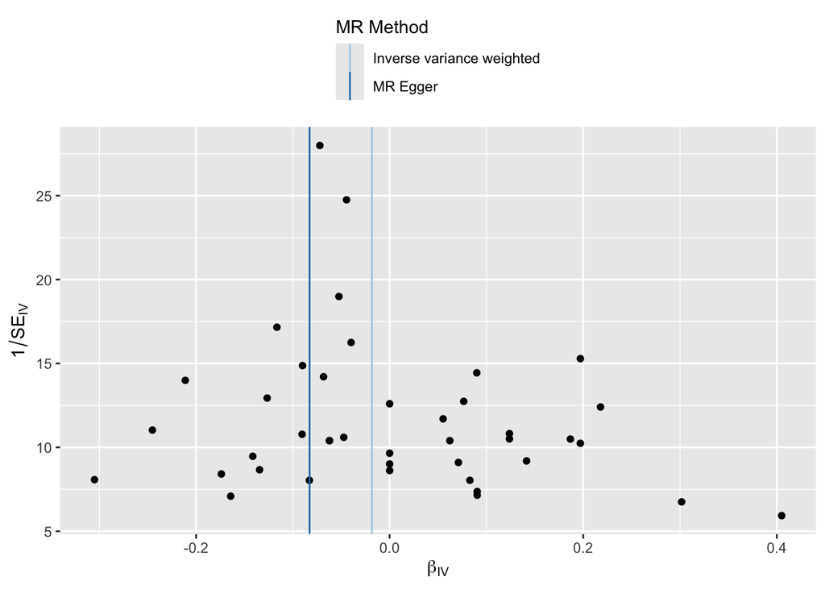

```r
# Funnel plot
p4_res_single_anm_T2D <- mr_funnel_plot(res_single_anm_T2D)
p4_res_single_anm_T2D[[1]]
```

```r
# Leave-one-out
res_loo_anm_T2D <- mr_leaveoneout(harmonized_data_anm_T2D)
head(res_loo_anm_T2D)
```

```
                           exposure                                outcome
1 Age at menopause || id:ieu-a-1004 Type 2 diabetes || id:ebi-a-GCST005047
2 Age at menopause || id:ieu-a-1004 Type 2 diabetes || id:ebi-a-GCST005047
3 Age at menopause || id:ieu-a-1004 Type 2 diabetes || id:ebi-a-GCST005047
4 Age at menopause || id:ieu-a-1004 Type 2 diabetes || id:ebi-a-GCST005047
5 Age at menopause || id:ieu-a-1004 Type 2 diabetes || id:ebi-a-GCST005047
6 Age at menopause || id:ieu-a-1004 Type 2 diabetes || id:ebi-a-GCST005047
  id.exposure       id.outcome samplesize        SNP           b         se
1  ieu-a-1004 ebi-a-GCST005047      12171  rs1046089 -0.01569578 0.01924708
2  ieu-a-1004 ebi-a-GCST005047      12171 rs10813912 -0.01932215 0.01906060
3  ieu-a-1004 ebi-a-GCST005047      12171 rs10905065 -0.01916527 0.01904653
4  ieu-a-1004 ebi-a-GCST005047      12171 rs10937153 -0.01215171 0.01850799
5  ieu-a-1004 ebi-a-GCST005047      12171 rs11031002 -0.01689549 0.01903845
6  ieu-a-1004 ebi-a-GCST005047      12171 rs11647580 -0.02079355 0.01895808
          p
1 0.4147925
2 0.3107153
3 0.3143029
4 0.5114603
5 0.3748418
6 0.2727211
```

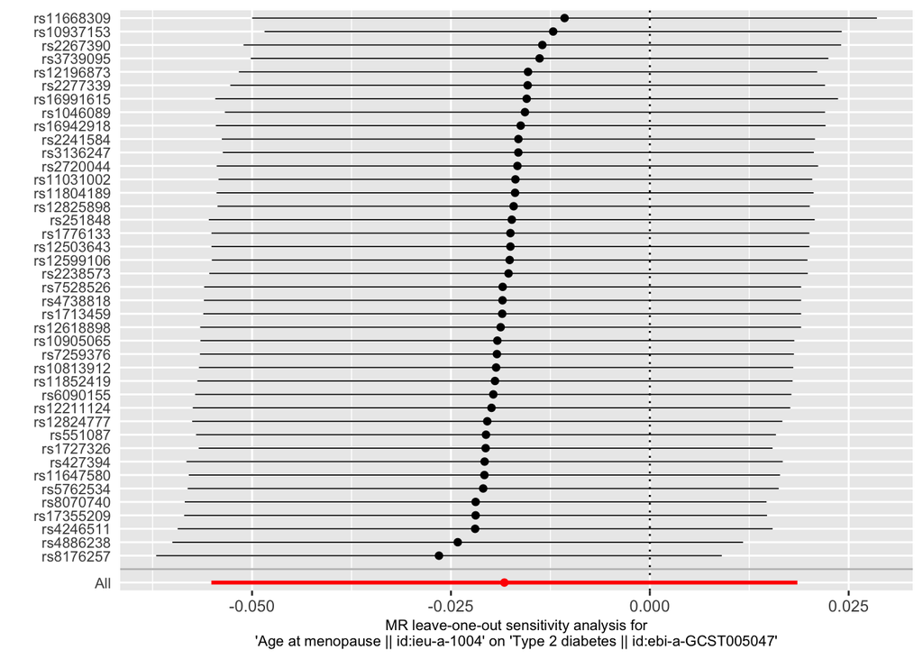

```r
p_loo_anm_T2D <- mr_leaveoneout_plot(res_loo_anm_T2D)
p_loo_anm_T2D[[1]]
```

```r
# Steiger directionality
out_anm_T2D <- directionality_test(harmonized_data_anm_T2D)
```

```
r.exposure and/or r.outcome not present.
```

```
Calculating approximate SNP-exposure and/or SNP-outcome correlations, assuming all are quantitative traits. Please pre-calculate r.exposure and/or r.outcome using get_r_from_lor() for any binary traits
```

```r
head(out_anm_T2D)
```

```
  id.exposure       id.outcome                          exposure
1  ieu-a-1004 ebi-a-GCST005047 Age at menopause || id:ieu-a-1004
                                 outcome snp_r2.exposure snp_r2.outcome
1 Type 2 diabetes || id:ebi-a-GCST005047      0.04007178    0.007322349
  correct_causal_direction steiger_pval
1                     TRUE 9.514891e-33
```

### 5.2.1 **Results for Forward MR (**ANM → T2D)

[output not shown]

The MR estimates were non significant except for Weighted Median and Weighted Mode.

**Sensitivity analyses**

- Heterogeneity -> Strong heterogeneity was observed, indicating inconsistent SNP effects and suggesting possible pleiotropic effects (MR-Egger p-value 2.779106e-05 and IVW Qpvalue 1.086847e-05).
- MR-Egger pleiotropy test -> The Egger intercept was not significant too (p-value 0.1518), indicating no strong evidence of directional pleiotropy.
- Steiger directionality test -> p = 9.514891e-33, confirming the correct causal direction is ANM to T2D, and that reverse causation is unlikely.
- Single SNP analysis( and the forest plot) -> Almost all the SNPs were non-significant, with some having positive and negative effect but showed no strong outliers dominating the results.
  - Funnel plot: The SNPs show symmetrical distribution.
- Leave-one-out analysis -> Most p-values remained insignificant, suggesting no SNP is driving the observed effect.
  - LOO plot -> Each dot represents the IVW estimate after removing one SNP at a time. Most of the estimates had a confidence interval crossing 0, indicating no SNP shifts/drives the effect.

**Conclusion:** Suggestive evidence that later age of menopause may be associated with reduced T2D. In the presence of strong heterogeneity as observed, this should be interpreted cautiously.

## 5.3 Multivariable MR

## 5.4 **Forward Multivariable MR (MVMR)**

Direction: ANM + BMI → T2D  
Exposures: ANM, Body Mass Index  
Outcome: Type 2 Diabetes  
Research Question: Does ANM affect T2D independent of BMI? and how does BMI affect T2D independent of ANM?

```r
###################################################
# Multivariable MR: anm + BMI -> T2D
##################################################
# Instruments for anm + BMI
exp_anm_mv <- mv_extract_exposures(
  id_exposure = c("ieu-a-1004", "ieu-a-2"), #anm and bmi
  clump_r2 = 0.001,
  clump_kb = 10000,
  pop = "EUR"
)
```

```
Please look at vignettes for options on running this locally if you need to run many instances of this command.
```

```
Clumping 1, 121 variants, using EUR population reference
```

```
Removing 13 of 121 variants due to LD with other variants or absence from LD reference panel
```

```
Extracting data for 108 SNP(s) from 2 GWAS(s)
```

```
Querying id chunk 1 of 1
```

```
Querying variant chunk 1 of 4
```

```
Querying variant chunk 2 of 4
```

```
Querying variant chunk 3 of 4
```

```
Querying variant chunk 4 of 4
```

```
Harmonising Age at menopause || id:ieu-a-1004 (ieu-a-1004) and Body mass index || id:ieu-a-2 (ieu-a-2)
```

```
Removing the following SNPs for being palindromic with intermediate allele frequencies:
rs11647580, rs12599106, rs1558902
```

```r
# Outcome: T2D
out_anm_T2D <- extract_outcome_data(
  snps     = exp_anm_mv$SNP,
  outcomes = "ebi-a-GCST005047" #t2d
)
```

```
Extracting data for 105 SNP(s) from 1 GWAS(s)
```

```
Querying id chunk 1 of 1
```

```
Querying variant chunk 1 of 2
```

```
Querying variant chunk 2 of 2
```

```
Finding proxies for 1 SNPs in outcome ebi-a-GCST005047
```

```
Extracting data for 1 SNP(s) from 1 GWAS(s)
```

```
Querying id chunk 1 of 1
```

```
Querying variant chunk 1 of 1
```

```r
# Harmonise
mv_anm_dat <- mv_harmonise_data(exp_anm_mv, out_anm_T2D)
```

```
Harmonising Age at menopause || id:ieu-a-1004 (ieu-a-1004) and Type 2 diabetes || id:ebi-a-GCST005047 (ebi-a-GCST005047)
```

```
Removing the following SNPs for being palindromic with intermediate allele frequencies:
rs11031002, rs11852419, rs14810, rs1727326, rs9304665, rs9579083
```

```r
# Multivariable MR
res_mvmr_anm <- mv_multiple(mv_anm_dat)
head(res_mvmr_anm)
```

```
$result
  id.exposure                          exposure       id.outcome
1  ieu-a-1004 Age at menopause || id:ieu-a-1004 ebi-a-GCST005047
2     ieu-a-2     Body mass index || id:ieu-a-2 ebi-a-GCST005047
                                 outcome nsnp            b         se
1 Type 2 diabetes || id:ebi-a-GCST005047   32 -0.009090498 0.03196364
2 Type 2 diabetes || id:ebi-a-GCST005047   66  0.599057008 0.16617247
          pval
1 0.7761029629
2 0.0003121151
```

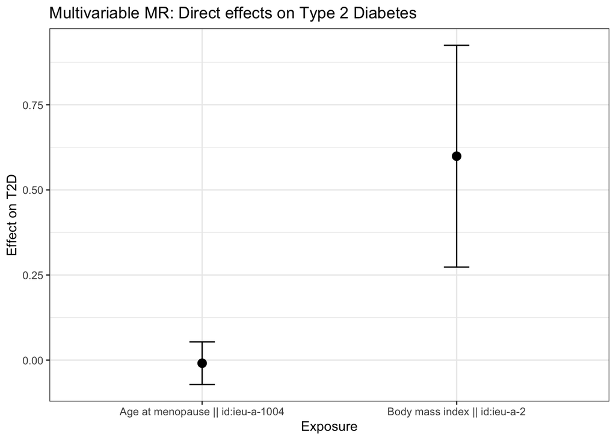

```r
# Main MVMR plot
ggplot(res_mvmr_anm$result, aes(x = exposure, y = b)) +
  geom_point(size = 3) +
  geom_errorbar(
    aes(ymin = b - 1.96 * se, ymax = b + 1.96 * se),
    width = 0.1
  ) +
  theme_bw() +
  labs(
    title = "Multivariable MR: Direct effects on Type 2 Diabetes",
    x = "Exposure",
    y = "Effect on T2D"
  )
```

#### 5.4.0.1 Results for Forward Multivariable MR (ANM + BMI → T2D)

| Exposure | β | SE | p-value | Interpretation |
| --- | --- | --- | --- | --- |
| Age at menopause (ANM) | -0.0091 | 0.0320 | 0.7761 | Not significant |
| Body mass index (BMI) | 0.5991 | 0.1662 | 0.00031 | Significant |

After adjusting for BMI, age at natural menopause has no direct causal effect on type 2 diabetes. However, Higher BMI has a strong direct causal effect increasing the risk of T2D.

## 5.5 **Reverse MR**

Direction: T2D → ANM  
Exposure: Type 2 Diabetes  
Outcome: ANM  
Research Question: Does T2D causally influence ANM?

```r
###################################################
#Reverse MR: T2D -> ANM
##################################################

# 1. Instruments for T2D (exposure)
exp_T2D <- extract_instruments("ebi-a-GCST005047") #t2d

exp_T2D_clumped <- clump_data(
  exp_T2D,
  clump_r2 = 0.001,
  clump_kb = 10000,
  pop = "EUR"
)
```

```
Please look at vignettes for options on running this locally if you need to run many instances of this command.
```

```
Clumping ebi-a-GCST005047, 34 variants, using EUR population reference
```

```r
exp_T2D_clumped$F_statistic <- (exp_T2D_clumped$beta.exposure^2) / (exp_T2D_clumped$se.exposure^2)
summary(exp_T2D_clumped$F_statistic)
```

```
   Min. 1st Qu.  Median    Mean 3rd Qu.    Max.
  23.00   41.10   49.40   81.31   71.09  546.36
```

```r
# 2. Outcome = ANM
out_anm <- extract_outcome_data(
  snps     = exp_T2D_clumped$SNP,
  outcomes = "ieu-a-1004"   # Age at Natural Menopause
)
```

```
Extracting data for 34 SNP(s) from 1 GWAS(s)
```

```
Querying id chunk 1 of 1
```

```
Querying variant chunk 1 of 1
```

```r
# 3. Harmonise
harmonise_data_T2D_anm <- harmonise_data(
  exp_T2D_clumped,
  out_anm,
  action = 1
)
```

```
Harmonising Type 2 diabetes || id:ebi-a-GCST005047 (ebi-a-GCST005047) and Age at menopause || id:ieu-a-1004 (ieu-a-1004)
```

```r
# 4. Reverse MR
res_T2D_anm <- mr(harmonise_data_T2D_anm)
```

```
Analysing 'ebi-a-GCST005047' on 'ieu-a-1004'
```

```r
head(res_T2D_anm)
```

```
       id.exposure id.outcome                           outcome
1 ebi-a-GCST005047 ieu-a-1004 Age at menopause || id:ieu-a-1004
2 ebi-a-GCST005047 ieu-a-1004 Age at menopause || id:ieu-a-1004
3 ebi-a-GCST005047 ieu-a-1004 Age at menopause || id:ieu-a-1004
4 ebi-a-GCST005047 ieu-a-1004 Age at menopause || id:ieu-a-1004
5 ebi-a-GCST005047 ieu-a-1004 Age at menopause || id:ieu-a-1004
                                exposure                    method nsnp
1 Type 2 diabetes || id:ebi-a-GCST005047                  MR Egger   34
2 Type 2 diabetes || id:ebi-a-GCST005047           Weighted median   34
3 Type 2 diabetes || id:ebi-a-GCST005047 Inverse variance weighted   34
4 Type 2 diabetes || id:ebi-a-GCST005047               Simple mode   34
5 Type 2 diabetes || id:ebi-a-GCST005047             Weighted mode   34
           b         se      pval
1 0.09884349 0.09158075 0.2885204
2 0.04702547 0.05315651 0.3763397
3 0.05121845 0.03473182 0.1402976
4 0.05859010 0.08570359 0.4989772
5 0.04902114 0.05992547 0.4192049
```

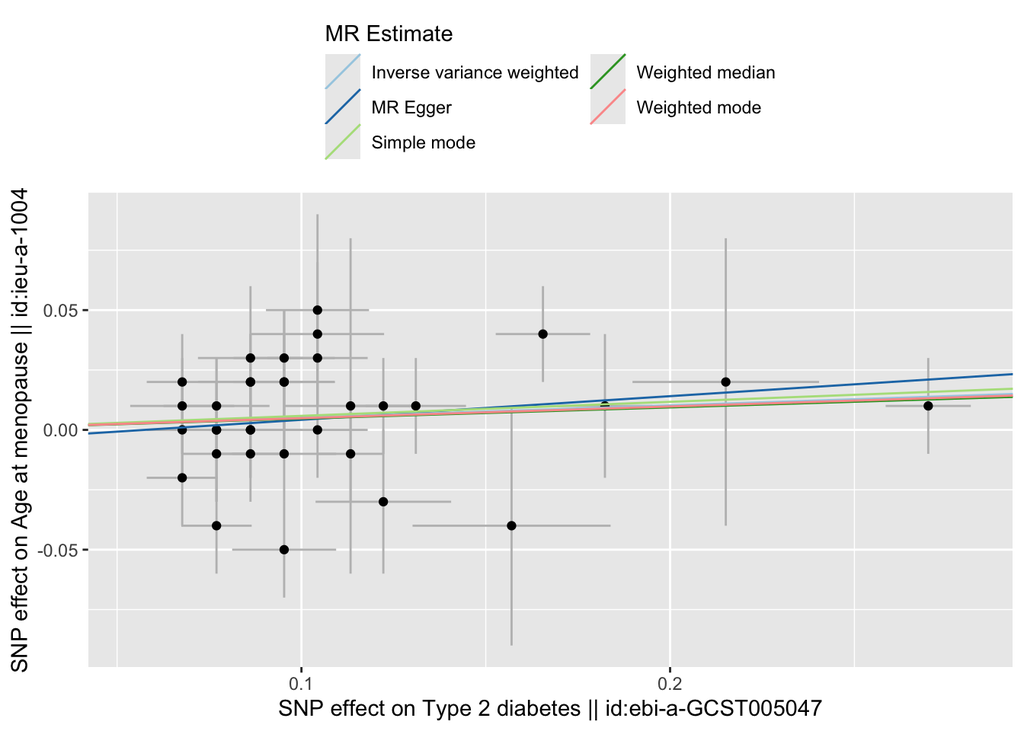

```r
# Scatter plot
p1_res_T2D_anm <- mr_scatter_plot(res_T2D_anm, harmonise_data_T2D_anm)
p1_res_T2D_anm[[1]]
```

```r
# Heterogeneity
mr_heterogeneity(harmonise_data_T2D_anm)
```

```
       id.exposure id.outcome                           outcome
1 ebi-a-GCST005047 ieu-a-1004 Age at menopause || id:ieu-a-1004
2 ebi-a-GCST005047 ieu-a-1004 Age at menopause || id:ieu-a-1004
                                exposure                    method        Q
1 Type 2 diabetes || id:ebi-a-GCST005047                  MR Egger 30.17680
2 Type 2 diabetes || id:ebi-a-GCST005047 Inverse variance weighted 30.49266
  Q_df    Q_pval
1   32 0.5590353
2   33 0.5925498
```

```r
# Pleiotropy
mr_pleiotropy_test(harmonise_data_T2D_anm)
```

```
       id.exposure id.outcome                           outcome
1 ebi-a-GCST005047 ieu-a-1004 Age at menopause || id:ieu-a-1004
                                exposure egger_intercept         se      pval
1 Type 2 diabetes || id:ebi-a-GCST005047    -0.005675704 0.01009878 0.5780189
```

```r
# Single-SNP MR
res_single_T2D_anm <- mr_singlesnp(harmonise_data_T2D_anm)
head(res_single_T2D_anm)
```

```
                                exposure                           outcome
1 Type 2 diabetes || id:ebi-a-GCST005047 Age at menopause || id:ieu-a-1004
2 Type 2 diabetes || id:ebi-a-GCST005047 Age at menopause || id:ieu-a-1004
3 Type 2 diabetes || id:ebi-a-GCST005047 Age at menopause || id:ieu-a-1004
4 Type 2 diabetes || id:ebi-a-GCST005047 Age at menopause || id:ieu-a-1004
5 Type 2 diabetes || id:ebi-a-GCST005047 Age at menopause || id:ieu-a-1004
6 Type 2 diabetes || id:ebi-a-GCST005047 Age at menopause || id:ieu-a-1004
       id.exposure id.outcome samplesize        SNP          b        se
1 ebi-a-GCST005047 ieu-a-1004      69360 rs10099941 -0.2956017 0.2956017
2 ebi-a-GCST005047 ieu-a-1004      69360 rs10258074  0.0000000 0.2320786
3 ebi-a-GCST005047 ieu-a-1004      69360 rs10830961  0.2320786 0.2320786
4 ebi-a-GCST005047 ieu-a-1004      69360 rs10842993  0.3481179 0.3481179
5 ebi-a-GCST005047 ieu-a-1004      69360 rs11257655  0.2098411 0.3147617
6 ebi-a-GCST005047 ieu-a-1004      69360 rs11708067 -0.5246028 0.2098411
           p
1 0.31731051
2 1.00000000
3 0.31731051
4 0.31731051
5 0.50498508
6 0.01241933
```

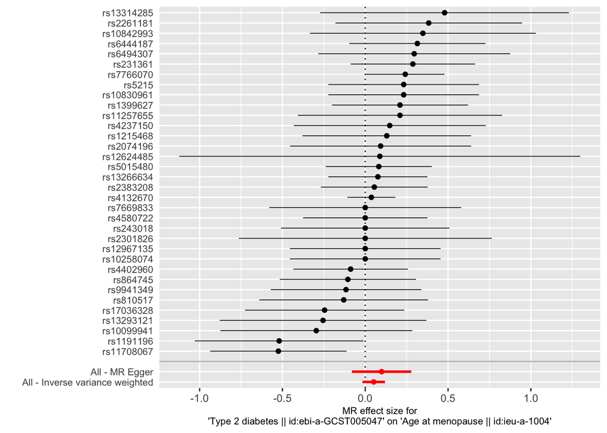

```r
# Forest plot
p2_res_single_T2D_anm <- mr_forest_plot(res_single_T2D_anm)
p2_res_single_T2D_anm[[1]]
```

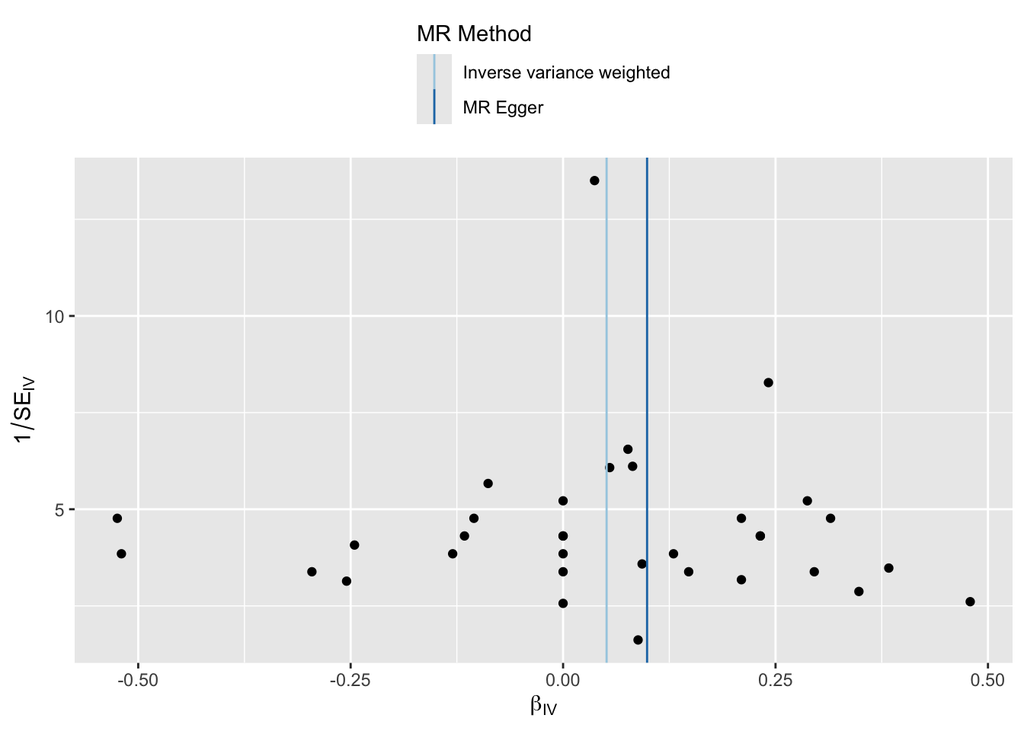

```r
# Funnel plot
p4_res_single_T2D_anm <- mr_funnel_plot(res_single_T2D_anm)
p4_res_single_T2D_anm[[1]]
```

```r
# Leave-one-out
res_loo_T2D_anm <- mr_leaveoneout(harmonise_data_T2D_anm)
head(res_loo_T2D_anm)
```

```
                                exposure                           outcome
1 Type 2 diabetes || id:ebi-a-GCST005047 Age at menopause || id:ieu-a-1004
2 Type 2 diabetes || id:ebi-a-GCST005047 Age at menopause || id:ieu-a-1004
3 Type 2 diabetes || id:ebi-a-GCST005047 Age at menopause || id:ieu-a-1004
4 Type 2 diabetes || id:ebi-a-GCST005047 Age at menopause || id:ieu-a-1004
5 Type 2 diabetes || id:ebi-a-GCST005047 Age at menopause || id:ieu-a-1004
6 Type 2 diabetes || id:ebi-a-GCST005047 Age at menopause || id:ieu-a-1004
       id.exposure id.outcome samplesize        SNP          b         se
1 ebi-a-GCST005047 ieu-a-1004      69360 rs10099941 0.05607337 0.03497407
2 ebi-a-GCST005047 ieu-a-1004      69360 rs10258074 0.05239185 0.03512742
3 ebi-a-GCST005047 ieu-a-1004      69360 rs10830961 0.04707497 0.03512742
4 ebi-a-GCST005047 ieu-a-1004      69360 rs10842993 0.04823336 0.03490598
5 ebi-a-GCST005047 ieu-a-1004      69360 rs11257655 0.04926331 0.03494521
6 ebi-a-GCST005047 ieu-a-1004      69360 rs11708067 0.06743749 0.03521757
           p
1 0.10887193
2 0.13583543
3 0.18020622
4 0.16703070
5 0.15861945
6 0.05550754
```

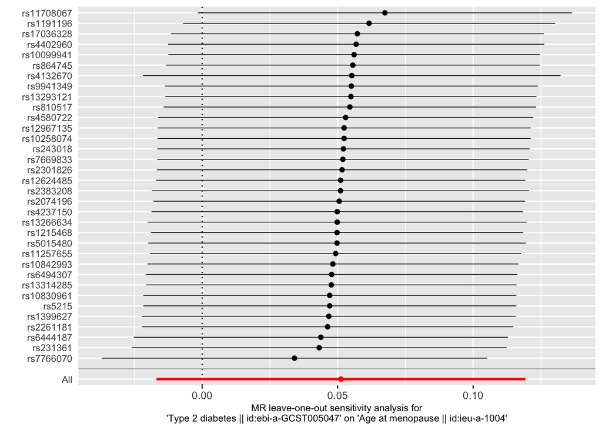

```r
p_loo_T2D_anm <- mr_leaveoneout_plot(res_loo_T2D_anm)
p_loo_T2D_anm[[1]]
```

```r
# Steiger directionality
out_T2D_anm <- directionality_test(harmonise_data_T2D_anm)
```

```
r.exposure and/or r.outcome not present.
```

```
Calculating approximate SNP-exposure and/or SNP-outcome correlations, assuming all are quantitative traits. Please pre-calculate r.exposure and/or r.outcome using get_r_from_lor() for any binary traits
```

```r
head(out_T2D_anm)
```

```
       id.exposure id.outcome                               exposure
1 ebi-a-GCST005047 ieu-a-1004 Type 2 diabetes || id:ebi-a-GCST005047
                            outcome snp_r2.exposure snp_r2.outcome
1 Age at menopause || id:ieu-a-1004       0.1541034     0.00037895
  correct_causal_direction steiger_pval
1                     TRUE            0
```

#### 5.5.0.1 Results for Reverse MR (T2D → ANM)

| Method | β (Effect) | SE | p-value | Interpretation |
| --- | --- | --- | --- | --- |
| **MR-Egger** | 0.0988 | 0.0916 | 0.2885 | Not significant |
| **Weighted Median** | 0.0470 | 0.0557 | 0.3988 | Not significant |
| **IVW** | 0.0512 | 0.0347 | 0.1403 | Not significant |
| **Simple Mode** | 0.0586 | 0.0915 | 0.5262 | Not significant |
| **Weighted Mode** | 0.0490 | 0.0621 | 0.4354 | Not significant |

Based on the effects on the table and their distribution on the MR scatter plot, T2D could delay menopause, but since all of the estimates are not significant, therefore no causal effect of T2D on ANM

**Sensitivity analyses**

- Heterogeneity -> Heterogeneity was not observed (MR Egger and IVW Qp-values 0.5590 and 0.5925 respectively), indicating consistent SNP effects and suggesting no possible pleiotropic effects.
- MR-Egger pleiotropy test -> The egger intercept was not significant (p-value 0.5780), indicating no directional pleiotropy.
- Steiger directionality test -> p = 0 which is significant, causal direction is correct T2D to ANM.
- Single SNP analysis (and the forest plots) -> Most of the SNPs were not significant (p-values >0.05 and CI crossing 0). The effect sizes go in both positive and negative directions and with no consistent patterns. The MR-Egger and IVW estimate, were overlapping and crossing 0, thus not significant, indicating no single SNP showed significant drivers.
  - Funnel plot: The SNPs show symmetrical distribution.
- Leave-one-out analysis -> All p-values remained insignificant, suggesting no SNP is driving the observed effect.
  - LOO plot -> Each dot represents the IVW estimate after removing one SNP at a time. All the estimates were more than 0 but the confidence intervals were crossing 0, indicating no SNP shifts/drives the effect.

Conclusion: This MR analysis provides no evidence that the T2D has a direct causal effect on age at natural menopause.

## 5.6 **Reverse Multivariable MR (MVMR)**

```r
###################################################
# Reverse MVMR: T2D + BMI -> ANM
###################################################

# 1. Exposures = T2D + BMI
exp_mv_rev_anm <- mv_extract_exposures(
  id_exposure = c(
    "ebi-a-GCST005047",   # T2D liability
    "ieu-a-2"            # BMI
  ),
  clump_r2 = 0.001,
  clump_kb = 10000,
  pop = "EUR"
)
```

```
Please look at vignettes for options on running this locally if you need to run many instances of this command.
```

```
Clumping 1, 112 variants, using EUR population reference
```

```
Removing 11 of 112 variants due to LD with other variants or absence from LD reference panel
```

```
Extracting data for 101 SNP(s) from 2 GWAS(s)
```

```
Querying id chunk 1 of 1
```

```
Querying variant chunk 1 of 4
```

```
Querying variant chunk 2 of 4
```

```
Querying variant chunk 3 of 4
```

```
Querying variant chunk 4 of 4
```

```
Finding proxies for 1 SNPs in outcome ebi-a-GCST005047
```

```
Extracting data for 1 SNP(s) from 1 GWAS(s)
```

```
Querying id chunk 1 of 1
```

```
Querying variant chunk 1 of 1
```

```
Harmonising Type 2 diabetes || id:ebi-a-GCST005047 (ebi-a-GCST005047) and Body mass index || id:ieu-a-2 (ieu-a-2)
```

```
Removing the following SNPs for being palindromic with intermediate allele frequencies:
rs10258074, rs14810, rs1558902, rs17001654, rs4237150, rs6494307, rs9304665, rs9579083, rs9914578
```

```r
# 2. Outcome = ANM
out_anm_rev <- extract_outcome_data(
  snps     = exp_mv_rev_anm$SNP,
  outcomes = "ieu-a-1004"   # Age at Natural Menopause
)
```

```
Extracting data for 91 SNP(s) from 1 GWAS(s)
```

```
Querying id chunk 1 of 1
```

```
Querying variant chunk 1 of 2
```

```
Querying variant chunk 2 of 2
```

```r
# 3. Harmonise
mvdat_rev_T2D_anm <- mv_harmonise_data(
  exp_mv_rev_anm,
  out_anm_rev
)
```

```
Harmonising Type 2 diabetes || id:ebi-a-GCST005047 (ebi-a-GCST005047) and Age at menopause || id:ieu-a-1004 (ieu-a-1004)
```

```r
# 4. Reverse multivariable MR
res_mvmr_rev_T2D_anm <- mv_multiple(mvdat_rev_T2D_anm)
res_mvmr_rev_T2D_anm$result
```

```
       id.exposure                               exposure id.outcome
1 ebi-a-GCST005047 Type 2 diabetes || id:ebi-a-GCST005047 ieu-a-1004
2          ieu-a-2          Body mass index || id:ieu-a-2 ieu-a-1004
                            outcome nsnp           b         se      pval
1 Age at menopause || id:ieu-a-1004   26  0.06515825 0.04620489 0.1584799
2 Age at menopause || id:ieu-a-1004   67 -0.20322877 0.13167932 0.1227431
```

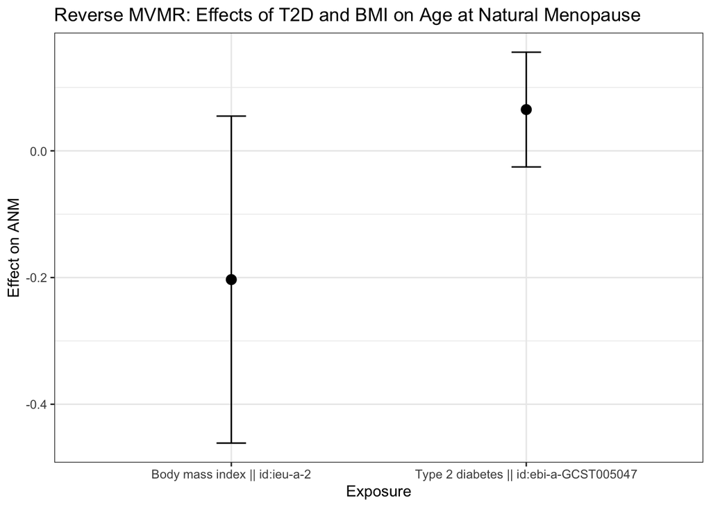

```r
# 5. Plot reverse MVMR
ggplot(res_mvmr_rev_T2D_anm$result, aes(x = exposure, y = b)) +
  geom_point(size = 3) +
  geom_errorbar(
    aes(ymin = b - 1.96 * se, ymax = b + 1.96 * se),
    width = 0.1
  ) +
  theme_bw() +
  labs(
    title = "Reverse MVMR: Effects of T2D and BMI on Age at Natural Menopause",
    x = "Exposure",
    y = "Effect on ANM"
  )
```

| Exposure | β | SE | p-value |  |
| --- | --- | --- | --- | --- |
| **T2D** | 0.0652 | 0.0462 | 0.1585 | Not significant |
| **Body Mass Index** | -0.2032 | 0.1317 | 0.1227 | Not significant |

BMI and T2D does not influence age of natural menopause.

## 5.7 Age at Menopause (ANM) and Lipid levels

## 5.8 **Forward MR**

Direction: ANM → LDL, ANM → HDL, ANM → TG, ANM →TC  
Exposure: ANM  
Outcome: LDL, HDL, TG, TC  
Research Question: Does ANM causally influence each lipid levels?

```r
###################################################
# Forward MR: ANM -> Lipids
###################################################

### We already have clumped_exp_anm from the previous MR (T2D)

lipids <- c(
  "ebi-a-GCST002222",  # LDL
  "ebi-a-GCST002223",  # HDL
  "ebi-a-GCST002216",  # Triglycerides
  "ebi-a-GCST002221"   # Total Cholesterol
)

### Loop ANM -> Lipids MR
mr_results_anm_to_lipids <- list()
harmonised_results_anm <- list()

for(lipid in lipids){

  outcome_lipids <- extract_outcome_data(
    snps     = clumped_exp_anm$SNP,
    outcomes = lipid
  )

  harmonise_data_anm_to_lipids <- harmonise_data(
    exposure_dat = clumped_exp_anm,
    outcome_dat  = outcome_lipids
  )

  harmonised_results_anm[[lipid]] <- harmonise_data_anm_to_lipids

  if(nrow(harmonise_data_anm_to_lipids) > 3){
    res_anm_to_lipids <- mr(harmonise_data_anm_to_lipids)
  } else {
    res_anm_to_lipids <- NA
  }

  mr_results_anm_to_lipids[[lipid]] <- res_anm_to_lipids
}
```

```
Extracting data for 41 SNP(s) from 1 GWAS(s)
```

```
Querying id chunk 1 of 1
```

```
Querying variant chunk 1 of 1
```

```
Harmonising Age at menopause || id:ieu-a-1004 (ieu-a-1004) and LDL cholesterol || id:ebi-a-GCST002222 (ebi-a-GCST002222)
```

```
Removing the following SNPs for being palindromic with intermediate allele frequencies:
rs11031002, rs11647580, rs11852419, rs12599106, rs1727326
```

```
Analysing 'ieu-a-1004' on 'ebi-a-GCST002222'
```

```
Extracting data for 41 SNP(s) from 1 GWAS(s)
```

```
Querying id chunk 1 of 1
```

```
Querying variant chunk 1 of 1
```

```
Harmonising Age at menopause || id:ieu-a-1004 (ieu-a-1004) and HDL cholesterol || id:ebi-a-GCST002223 (ebi-a-GCST002223)
```

```
Removing the following SNPs for being palindromic with intermediate allele frequencies:
rs11031002, rs11647580, rs11852419, rs12599106, rs1727326
```

```
Analysing 'ieu-a-1004' on 'ebi-a-GCST002223'
```

```
Extracting data for 41 SNP(s) from 1 GWAS(s)
```

```
Querying id chunk 1 of 1
```

```
Querying variant chunk 1 of 1
```

```
Harmonising Age at menopause || id:ieu-a-1004 (ieu-a-1004) and Triglycerides || id:ebi-a-GCST002216 (ebi-a-GCST002216)
```

```
Removing the following SNPs for being palindromic with intermediate allele frequencies:
rs11031002, rs11647580, rs11852419, rs12599106, rs1727326
```

```
Analysing 'ieu-a-1004' on 'ebi-a-GCST002216'
```

```
Extracting data for 41 SNP(s) from 1 GWAS(s)
```

```
Querying id chunk 1 of 1
```

```
Querying variant chunk 1 of 1
```

```
Harmonising Age at menopause || id:ieu-a-1004 (ieu-a-1004) and Cholesterol, total || id:ebi-a-GCST002221 (ebi-a-GCST002221)
```

```
Removing the following SNPs for being palindromic with intermediate allele frequencies:
rs11031002, rs11647580, rs11852419, rs12599106, rs1727326
```

```
Analysing 'ieu-a-1004' on 'ebi-a-GCST002221'
```

```r
mr_results_anm_to_lipids
```

```
$`ebi-a-GCST002222`
  id.exposure       id.outcome                                outcome
1  ieu-a-1004 ebi-a-GCST002222 LDL cholesterol || id:ebi-a-GCST002222
2  ieu-a-1004 ebi-a-GCST002222 LDL cholesterol || id:ebi-a-GCST002222
3  ieu-a-1004 ebi-a-GCST002222 LDL cholesterol || id:ebi-a-GCST002222
4  ieu-a-1004 ebi-a-GCST002222 LDL cholesterol || id:ebi-a-GCST002222
5  ieu-a-1004 ebi-a-GCST002222 LDL cholesterol || id:ebi-a-GCST002222
                           exposure                    method nsnp
1 Age at menopause || id:ieu-a-1004                  MR Egger   36
2 Age at menopause || id:ieu-a-1004           Weighted median   36
3 Age at menopause || id:ieu-a-1004 Inverse variance weighted   36
4 Age at menopause || id:ieu-a-1004               Simple mode   36
5 Age at menopause || id:ieu-a-1004             Weighted mode   36
              b          se      pval
1  0.0005930935 0.009186307 0.9489002
```

[output cut: 64 more lines]

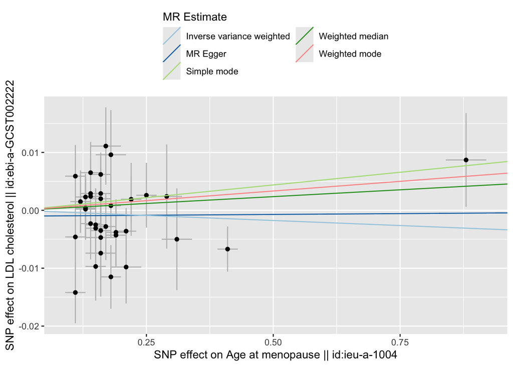

```r
#############################
### Plot results for ANM_to_LDL
data_anm_to_ldl <- harmonised_results_anm[["ebi-a-GCST002222"]]
res_anm_to_ldl  <- mr_results_anm_to_lipids[["ebi-a-GCST002222"]]

p1_res_anm_to_ldl <- mr_scatter_plot(res_anm_to_ldl, data_anm_to_ldl)
p1_res_anm_to_ldl[[1]]
```

```r
mr_heterogeneity(data_anm_to_ldl)
```

```
  id.exposure       id.outcome                                outcome
1  ieu-a-1004 ebi-a-GCST002222 LDL cholesterol || id:ebi-a-GCST002222
2  ieu-a-1004 ebi-a-GCST002222 LDL cholesterol || id:ebi-a-GCST002222
                           exposure                    method        Q Q_df
1 Age at menopause || id:ieu-a-1004                  MR Egger 37.17082   34
2 Age at menopause || id:ieu-a-1004 Inverse variance weighted 37.45394   35
     Q_pval
1 0.3250851
2 0.3571639
```

```r
mr_pleiotropy_test(data_anm_to_ldl)
```

```
  id.exposure       id.outcome                                outcome
1  ieu-a-1004 ebi-a-GCST002222 LDL cholesterol || id:ebi-a-GCST002222
                           exposure egger_intercept          se      pval
1 Age at menopause || id:ieu-a-1004    -0.001002438 0.001969862 0.6141177
```

```r
res_single_anm_to_ldl <- mr_singlesnp(data_anm_to_ldl)
head(res_single_anm_to_ldl)
```

```
                           exposure                                outcome
1 Age at menopause || id:ieu-a-1004 LDL cholesterol || id:ebi-a-GCST002222
2 Age at menopause || id:ieu-a-1004 LDL cholesterol || id:ebi-a-GCST002222
3 Age at menopause || id:ieu-a-1004 LDL cholesterol || id:ebi-a-GCST002222
4 Age at menopause || id:ieu-a-1004 LDL cholesterol || id:ebi-a-GCST002222
5 Age at menopause || id:ieu-a-1004 LDL cholesterol || id:ebi-a-GCST002222
6 Age at menopause || id:ieu-a-1004 LDL cholesterol || id:ebi-a-GCST002222
  id.exposure       id.outcome samplesize        SNP            b          se
1  ieu-a-1004 ebi-a-GCST002222      94595  rs1046089  0.008636364 0.018181818
2  ieu-a-1004 ebi-a-GCST002222      94595 rs10813912  0.012500000 0.045000000
3  ieu-a-1004 ebi-a-GCST002222      94595 rs10905065 -0.129090909 0.048181818
4  ieu-a-1004 ebi-a-GCST002222      94595 rs10937153 -0.016428571 0.044285714
5  ieu-a-1004 ebi-a-GCST002222      94595 rs11668309 -0.016341463 0.009512195
6  ieu-a-1004 ebi-a-GCST002222      94595 rs11804189  0.053636364 0.049090909
            p
1 0.634786973
2 0.781182951
3 0.007378832
4 0.710661558
5 0.085805970
6 0.274572716
```

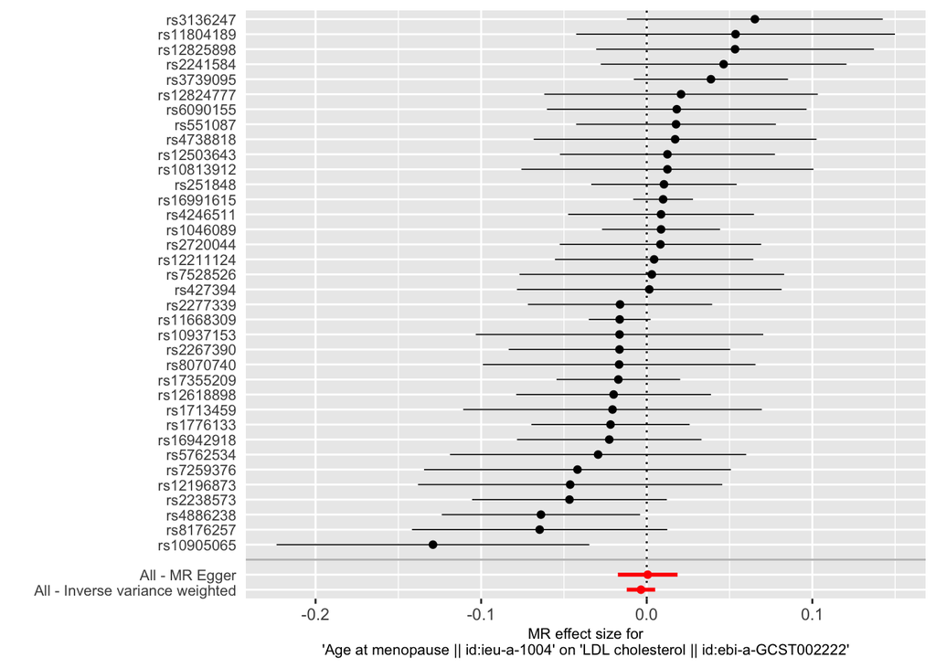

```r
p2_res_single_anm_to_ldl <- mr_forest_plot(res_single_anm_to_ldl)
p2_res_single_anm_to_ldl[[1]]
```

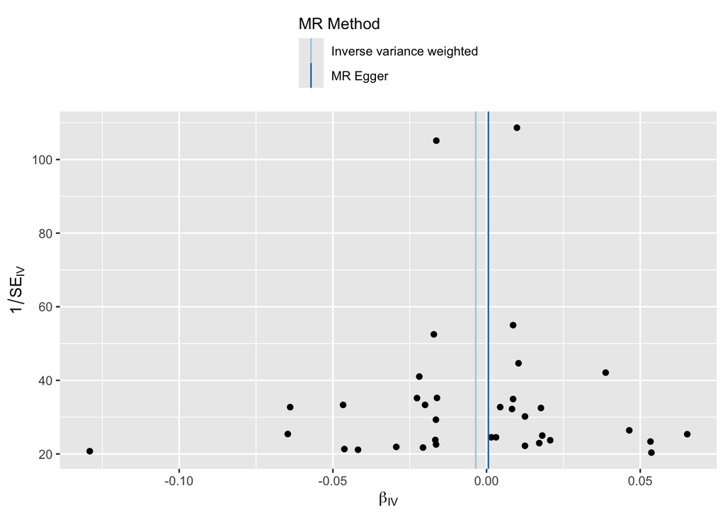

```r
p4_res_single_anm_to_ldl <- mr_funnel_plot(res_single_anm_to_ldl)
p4_res_single_anm_to_ldl[[1]]
```

```r
res_loo_anm_to_ldl <- mr_leaveoneout(data_anm_to_ldl)
head(res_loo_anm_to_ldl)
```

```
                           exposure                                outcome
1 Age at menopause || id:ieu-a-1004 LDL cholesterol || id:ebi-a-GCST002222
2 Age at menopause || id:ieu-a-1004 LDL cholesterol || id:ebi-a-GCST002222
3 Age at menopause || id:ieu-a-1004 LDL cholesterol || id:ebi-a-GCST002222
4 Age at menopause || id:ieu-a-1004 LDL cholesterol || id:ebi-a-GCST002222
5 Age at menopause || id:ieu-a-1004 LDL cholesterol || id:ebi-a-GCST002222
6 Age at menopause || id:ieu-a-1004 LDL cholesterol || id:ebi-a-GCST002222
  id.exposure       id.outcome samplesize        SNP             b          se
1  ieu-a-1004 ebi-a-GCST002222      94595  rs1046089 -0.0041991573 0.004542588
2  ieu-a-1004 ebi-a-GCST002222      94595 rs10813912 -0.0036455906 0.004457874
3  ieu-a-1004 ebi-a-GCST002222      94595 rs10905065 -0.0025243900 0.004252181
4  ieu-a-1004 ebi-a-GCST002222      94595 rs10937153 -0.0033832031 0.004461006
5  ieu-a-1004 ebi-a-GCST002222      94595 rs11668309 -0.0003271189 0.004812110
6  ieu-a-1004 ebi-a-GCST002222      94595 rs11804189 -0.0039311194 0.004380238
          p
1 0.3552793
2 0.4134789
3 0.5527332
4 0.4482148
5 0.9458029
6 0.3694697
```

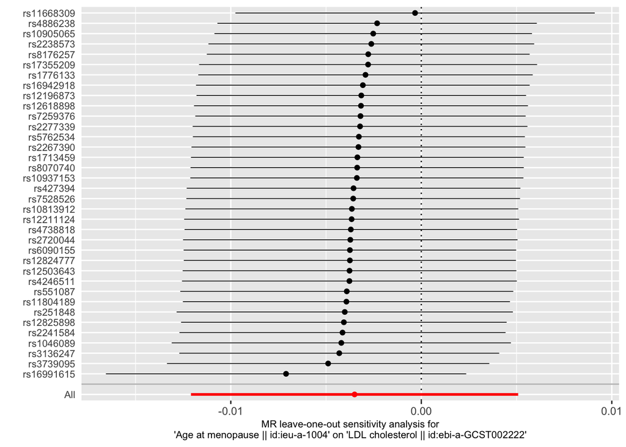

```r
p_loo_anm_to_ldl <- mr_leaveoneout_plot(res_loo_anm_to_ldl)
p_loo_anm_to_ldl[[1]]
```

```r
out_anm_to_ldl <- directionality_test(data_anm_to_ldl)
```

```
r.exposure and/or r.outcome not present.
```

```
Calculating approximate SNP-exposure and/or SNP-outcome correlations, assuming all are quantitative traits. Please pre-calculate r.exposure and/or r.outcome using get_r_from_lor() for any binary traits
```

```r
out_anm_to_ldl
```

```
  id.exposure       id.outcome                          exposure
1  ieu-a-1004 ebi-a-GCST002222 Age at menopause || id:ieu-a-1004
                                 outcome snp_r2.exposure snp_r2.outcome
1 LDL cholesterol || id:ebi-a-GCST002222      0.04007178   0.0004438736
  correct_causal_direction  steiger_pval
1                     TRUE 9.850347e-290
```

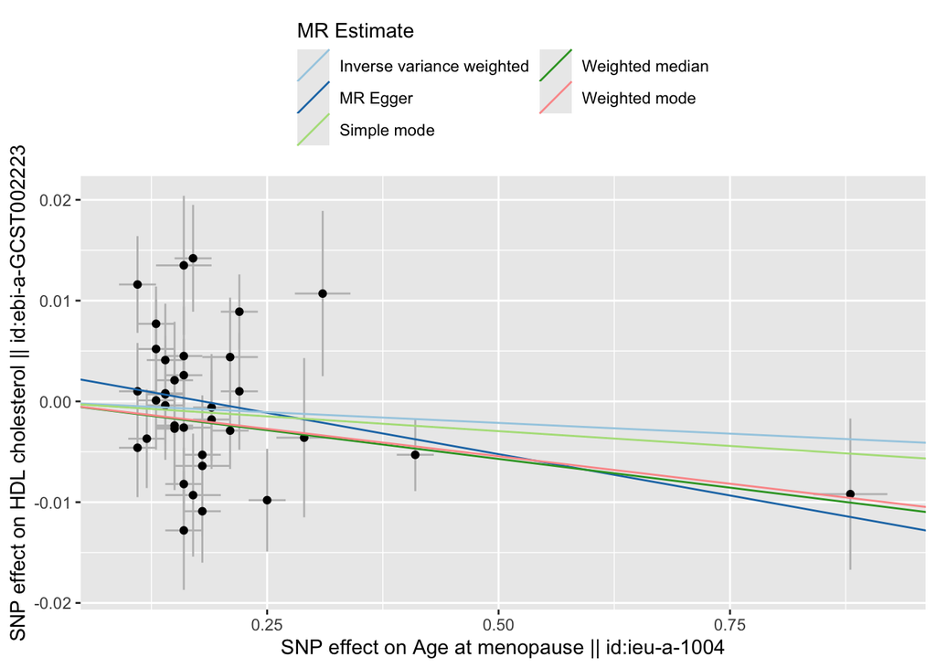

```r
#############################
### Plot results for ANM_to_HDL
data_anm_to_hdl <- harmonised_results_anm[["ebi-a-GCST002223"]]
res_anm_to_hdl  <- mr_results_anm_to_lipids[["ebi-a-GCST002223"]]

p1_res_anm_to_hdl <- mr_scatter_plot(res_anm_to_hdl, data_anm_to_hdl)
p1_res_anm_to_hdl[[1]]
```

```r
mr_heterogeneity(data_anm_to_hdl)
```

```
  id.exposure       id.outcome                                outcome
1  ieu-a-1004 ebi-a-GCST002223 HDL cholesterol || id:ebi-a-GCST002223
2  ieu-a-1004 ebi-a-GCST002223 HDL cholesterol || id:ebi-a-GCST002223
                           exposure                    method        Q Q_df
1 Age at menopause || id:ieu-a-1004                  MR Egger 57.39349   34
2 Age at menopause || id:ieu-a-1004 Inverse variance weighted 60.30970   35
       Q_pval
1 0.007305756
2 0.004957874
```

```r
mr_pleiotropy_test(data_anm_to_hdl)
```

```
  id.exposure       id.outcome                                outcome
1  ieu-a-1004 ebi-a-GCST002223 HDL cholesterol || id:ebi-a-GCST002223
                           exposure egger_intercept          se      pval
1 Age at menopause || id:ieu-a-1004      0.00296827 0.002258323 0.1975203
```

```r
res_single_anm_to_hdl <- mr_singlesnp(data_anm_to_hdl)
head(res_single_anm_to_hdl)
```

```
                           exposure                                outcome
1 Age at menopause || id:ieu-a-1004 HDL cholesterol || id:ebi-a-GCST002223
2 Age at menopause || id:ieu-a-1004 HDL cholesterol || id:ebi-a-GCST002223
3 Age at menopause || id:ieu-a-1004 HDL cholesterol || id:ebi-a-GCST002223
4 Age at menopause || id:ieu-a-1004 HDL cholesterol || id:ebi-a-GCST002223
5 Age at menopause || id:ieu-a-1004 HDL cholesterol || id:ebi-a-GCST002223
6 Age at menopause || id:ieu-a-1004 HDL cholesterol || id:ebi-a-GCST002223
  id.exposure       id.outcome samplesize        SNP            b          se
1  ieu-a-1004 ebi-a-GCST002223      94595  rs1046089  0.040454545 0.016818182
2  ieu-a-1004 ebi-a-GCST002223      94595 rs10813912 -0.030833333 0.040833333
3  ieu-a-1004 ebi-a-GCST002223      94595 rs10905065  0.105454545 0.043636364
4  ieu-a-1004 ebi-a-GCST002223      94595 rs10937153  0.005714286 0.040714286
5  ieu-a-1004 ebi-a-GCST002223      94595 rs11668309 -0.012926829 0.008780488
6  ieu-a-1004 ebi-a-GCST002223      94595 rs11804189 -0.041818182 0.044545455
           p
1 0.01615453
2 0.45018776
3 0.01566335
4 0.88838277
5 0.14096088
6 0.34784602
```

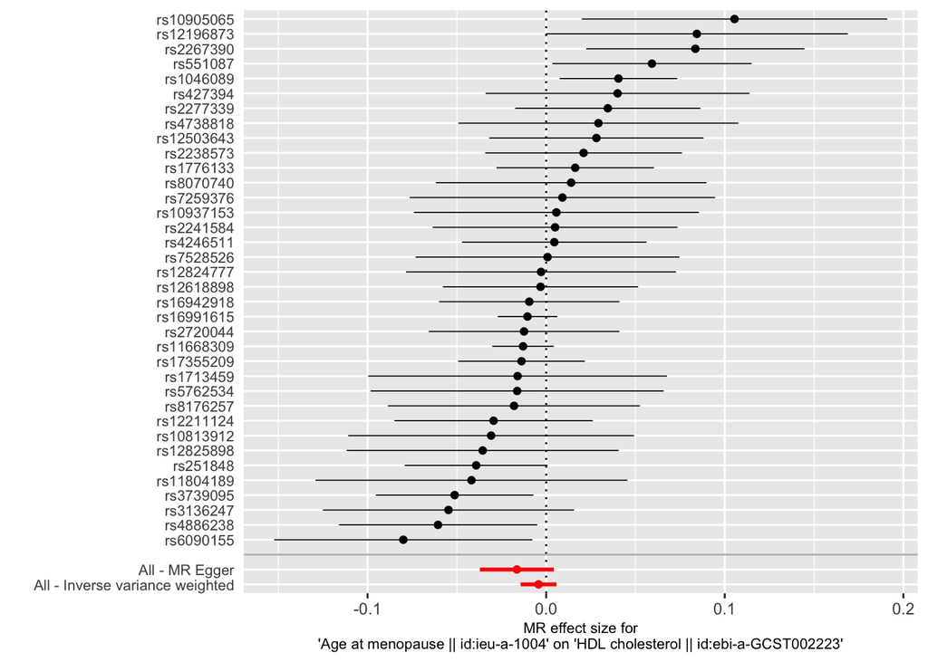

```r
p2_res_single_anm_to_hdl <- mr_forest_plot(res_single_anm_to_hdl)
p2_res_single_anm_to_hdl[[1]]
```

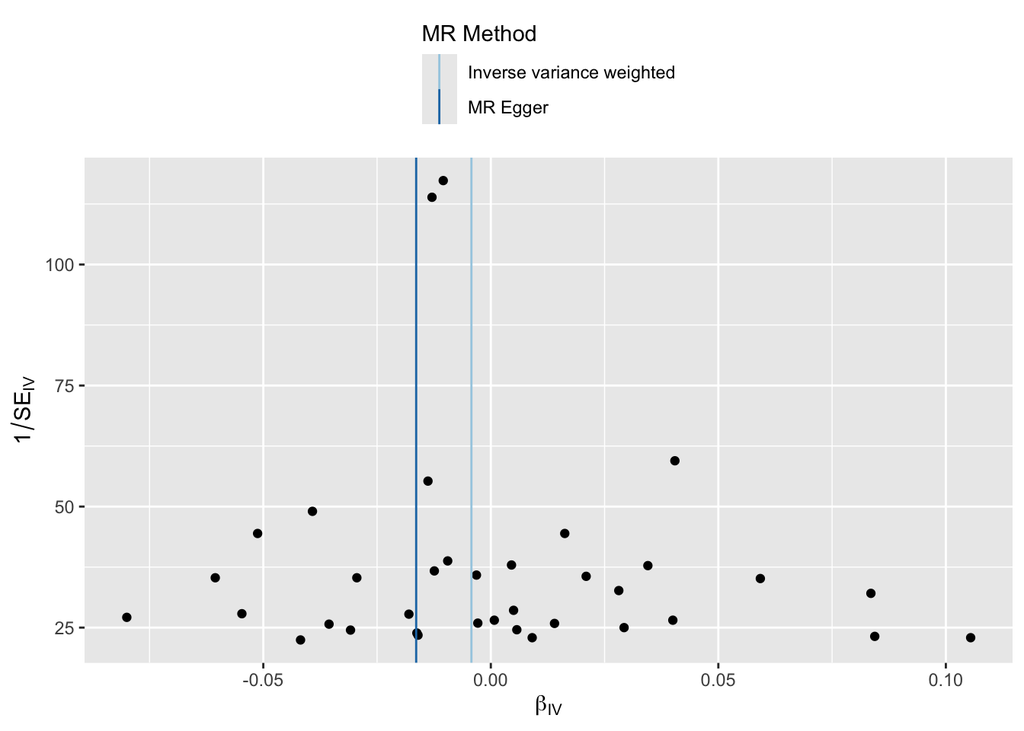

```r
p4_res_single_anm_to_hdl <- mr_funnel_plot(res_single_anm_to_hdl)
p4_res_single_anm_to_hdl[[1]]
```

```r
res_loo_anm_to_hdl <- mr_leaveoneout(data_anm_to_hdl)
head(res_loo_anm_to_hdl)
```

```
                           exposure                                outcome
1 Age at menopause || id:ieu-a-1004 HDL cholesterol || id:ebi-a-GCST002223
2 Age at menopause || id:ieu-a-1004 HDL cholesterol || id:ebi-a-GCST002223
3 Age at menopause || id:ieu-a-1004 HDL cholesterol || id:ebi-a-GCST002223
4 Age at menopause || id:ieu-a-1004 HDL cholesterol || id:ebi-a-GCST002223
5 Age at menopause || id:ieu-a-1004 HDL cholesterol || id:ebi-a-GCST002223
6 Age at menopause || id:ieu-a-1004 HDL cholesterol || id:ebi-a-GCST002223
  id.exposure       id.outcome samplesize        SNP            b          se
1  ieu-a-1004 ebi-a-GCST002223      94595  rs1046089 -0.006823979 0.005015016
2  ieu-a-1004 ebi-a-GCST002223      94595 rs10813912 -0.004018941 0.005216537
3  ieu-a-1004 ebi-a-GCST002223      94595 rs10905065 -0.005154399 0.004947920
4  ieu-a-1004 ebi-a-GCST002223      94595 rs10937153 -0.004358155 0.005232623
5  ieu-a-1004 ebi-a-GCST002223      94595 rs11668309 -0.002119108 0.005761988
6  ieu-a-1004 ebi-a-GCST002223      94595 rs11804189 -0.003973163 0.005200089
          p
1 0.1736056
2 0.4410489
3 0.2975366
4 0.4049116
5 0.7130419
6 0.4448334
```

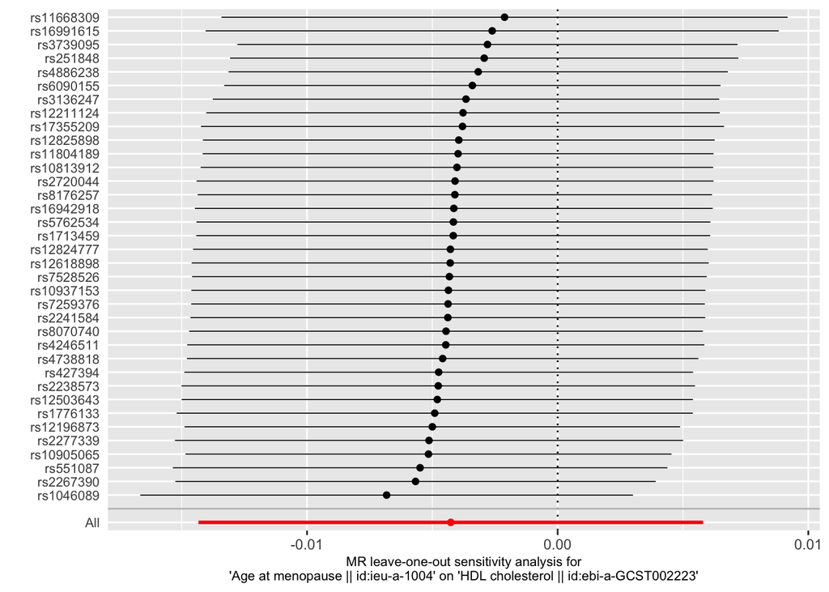

```r
p_loo_anm_to_hdl <- mr_leaveoneout_plot(res_loo_anm_to_hdl)
p_loo_anm_to_hdl[[1]]
```

```r
out_anm_to_hdl <- directionality_test(data_anm_to_hdl)
```

```
r.exposure and/or r.outcome not present.
Calculating approximate SNP-exposure and/or SNP-outcome correlations, assuming all are quantitative traits. Please pre-calculate r.exposure and/or r.outcome using get_r_from_lor() for any binary traits
```

```r
out_anm_to_hdl
```

```
  id.exposure       id.outcome                          exposure
1  ieu-a-1004 ebi-a-GCST002223 Age at menopause || id:ieu-a-1004
                                 outcome snp_r2.exposure snp_r2.outcome
1 HDL cholesterol || id:ebi-a-GCST002223      0.04007178   0.0005971503
  correct_causal_direction  steiger_pval
1                     TRUE 3.576071e-279
```

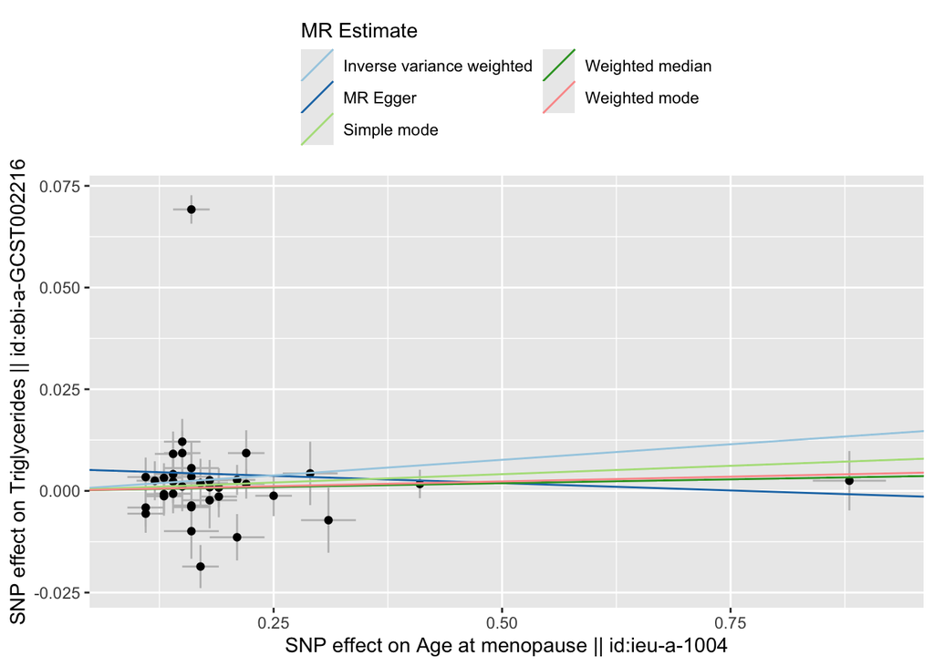

```r
#############################
### Plot results for ANM_to_TG
data_anm_to_tg <- harmonised_results_anm[["ebi-a-GCST002216"]]
res_anm_to_tg  <- mr_results_anm_to_lipids[["ebi-a-GCST002216"]]

p1_res_anm_to_tg <- mr_scatter_plot(res_anm_to_tg, data_anm_to_tg)
p1_res_anm_to_tg[[1]]
```

```r
mr_heterogeneity(data_anm_to_tg)
```

```
  id.exposure       id.outcome                              outcome
1  ieu-a-1004 ebi-a-GCST002216 Triglycerides || id:ebi-a-GCST002216
2  ieu-a-1004 ebi-a-GCST002216 Triglycerides || id:ebi-a-GCST002216
                           exposure                    method        Q Q_df
1 Age at menopause || id:ieu-a-1004                  MR Egger 406.2676   34
2 Age at menopause || id:ieu-a-1004 Inverse variance weighted 416.8569   35
        Q_pval
1 2.626883e-65
2 7.021756e-67
```

```r
mr_pleiotropy_test(data_anm_to_tg)
```

```
  id.exposure       id.outcome                              outcome
1  ieu-a-1004 ebi-a-GCST002216 Triglycerides || id:ebi-a-GCST002216
                           exposure egger_intercept          se      pval
1 Age at menopause || id:ieu-a-1004     0.005517303 0.005860849 0.3531497
```

```r
res_single_anm_to_tg <- mr_singlesnp(data_anm_to_tg)
head(res_single_anm_to_tg)
```

```
                           exposure                              outcome
1 Age at menopause || id:ieu-a-1004 Triglycerides || id:ebi-a-GCST002216
2 Age at menopause || id:ieu-a-1004 Triglycerides || id:ebi-a-GCST002216
3 Age at menopause || id:ieu-a-1004 Triglycerides || id:ebi-a-GCST002216
4 Age at menopause || id:ieu-a-1004 Triglycerides || id:ebi-a-GCST002216
5 Age at menopause || id:ieu-a-1004 Triglycerides || id:ebi-a-GCST002216
6 Age at menopause || id:ieu-a-1004 Triglycerides || id:ebi-a-GCST002216
  id.exposure       id.outcome samplesize        SNP            b          se
1  ieu-a-1004 ebi-a-GCST002216      94595  rs1046089  0.007727273 0.016363636
2  ieu-a-1004 ebi-a-GCST002216      94595 rs10813912  0.020833333 0.040000000
3  ieu-a-1004 ebi-a-GCST002216      94595 rs10905065 -0.050909091 0.042727273
4  ieu-a-1004 ebi-a-GCST002216      94595 rs10937153  0.029285714 0.039285714
5  ieu-a-1004 ebi-a-GCST002216      94595 rs11668309  0.004146341 0.008536585
6  ieu-a-1004 ebi-a-GCST002216      94595 rs11804189  0.030909091 0.043636364
          p
1 0.6367682
2 0.6024829
3 0.2334615
4 0.4559970
5 0.6271698
6 0.4787383
```

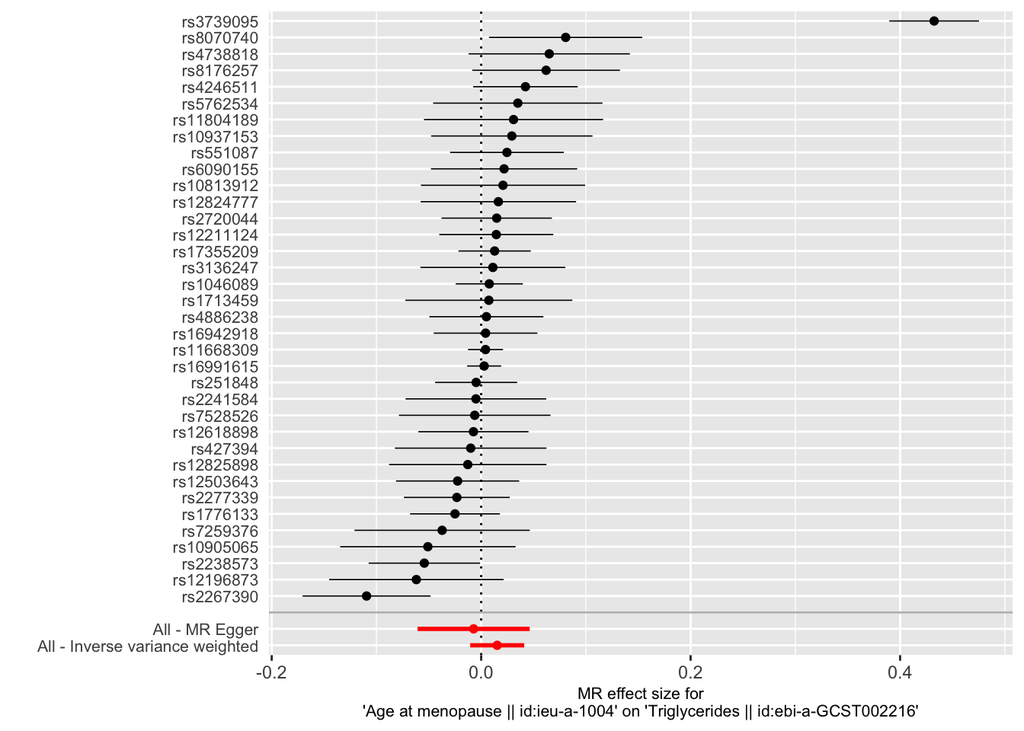

```r
p2_res_single_anm_to_tg <- mr_forest_plot(res_single_anm_to_tg)
p2_res_single_anm_to_tg[[1]]
```

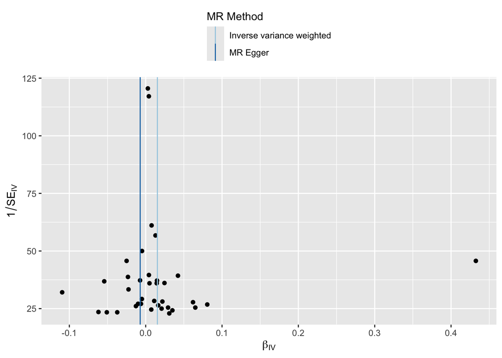

```r
p4_res_single_anm_to_tg <- mr_funnel_plot(res_single_anm_to_tg)
p4_res_single_anm_to_tg[[1]]
```

```r
res_loo_anm_to_tg <- mr_leaveoneout(data_anm_to_tg)
head(res_loo_anm_to_tg)
```

```
                           exposure                              outcome
1 Age at menopause || id:ieu-a-1004 Triglycerides || id:ebi-a-GCST002216
2 Age at menopause || id:ieu-a-1004 Triglycerides || id:ebi-a-GCST002216
3 Age at menopause || id:ieu-a-1004 Triglycerides || id:ebi-a-GCST002216
4 Age at menopause || id:ieu-a-1004 Triglycerides || id:ebi-a-GCST002216
5 Age at menopause || id:ieu-a-1004 Triglycerides || id:ebi-a-GCST002216
6 Age at menopause || id:ieu-a-1004 Triglycerides || id:ebi-a-GCST002216
  id.exposure       id.outcome samplesize        SNP          b         se
1  ieu-a-1004 ebi-a-GCST002216      94595  rs1046089 0.01575305 0.01373091
2  ieu-a-1004 ebi-a-GCST002216      94595 rs10813912 0.01526632 0.01341713
3  ieu-a-1004 ebi-a-GCST002216      94595 rs10905065 0.01584900 0.01337083
4  ieu-a-1004 ebi-a-GCST002216      94595 rs10937153 0.01518400 0.01341764
5  ieu-a-1004 ebi-a-GCST002216      94595 rs11668309 0.01810370 0.01489127
6  ieu-a-1004 ebi-a-GCST002216      94595 rs11804189 0.01519688 0.01340555
          p
1 0.2512705
2 0.2551944
3 0.2358824
4 0.2577840
5 0.2240896
6 0.2569513
```

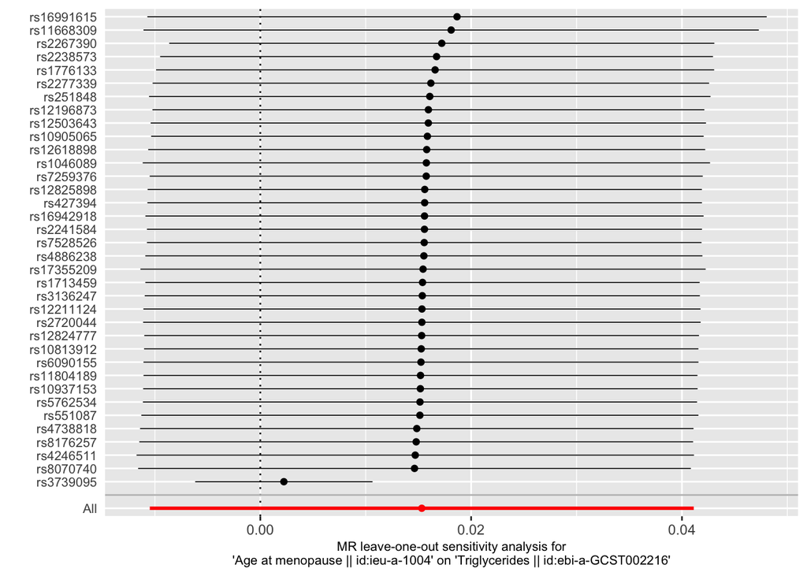

```r
p_loo_anm_to_tg <- mr_leaveoneout_plot(res_loo_anm_to_tg)
p_loo_anm_to_tg[[1]]
```

```r
out_anm_to_tg <- directionality_test(data_anm_to_tg)
```

```
r.exposure and/or r.outcome not present.
Calculating approximate SNP-exposure and/or SNP-outcome correlations, assuming all are quantitative traits. Please pre-calculate r.exposure and/or r.outcome using get_r_from_lor() for any binary traits
```

```r
out_anm_to_tg
```

```
  id.exposure       id.outcome                          exposure
1  ieu-a-1004 ebi-a-GCST002216 Age at menopause || id:ieu-a-1004
                               outcome snp_r2.exposure snp_r2.outcome
1 Triglycerides || id:ebi-a-GCST002216      0.04007178    0.004320613
  correct_causal_direction  steiger_pval
1                     TRUE 1.412319e-165
```

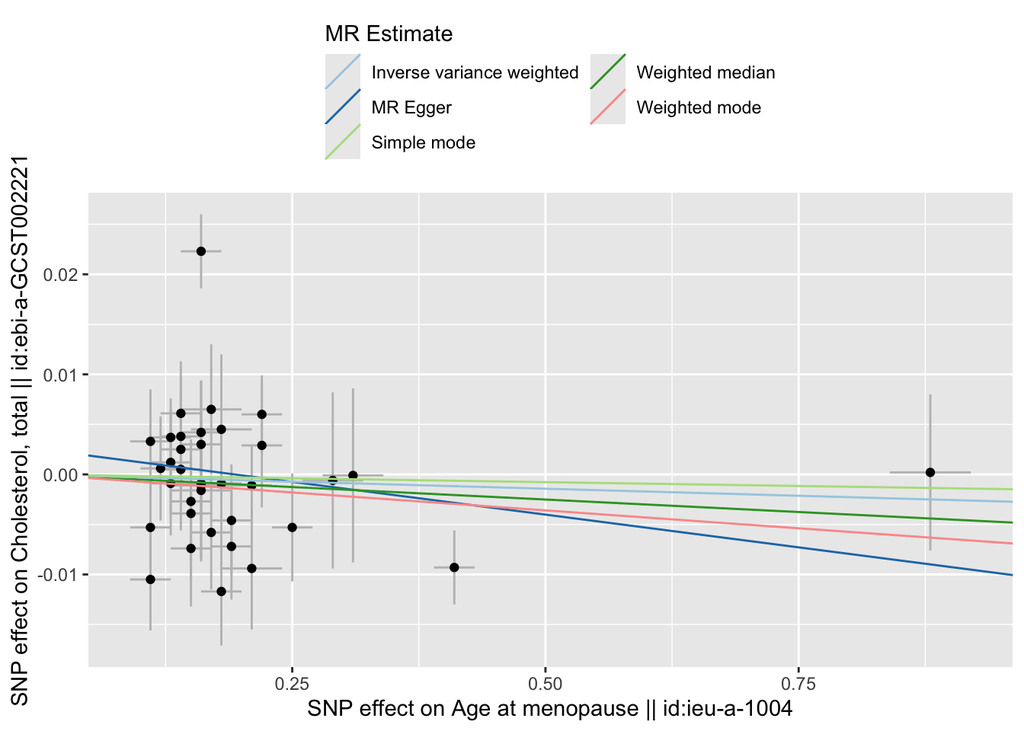

```r
#############################
### Plot results for ANM_to_TC
data_anm_to_tc <- harmonised_results_anm[["ebi-a-GCST002221"]]
res_anm_to_tc  <- mr_results_anm_to_lipids[["ebi-a-GCST002221"]]

p1_res_anm_to_tc <- mr_scatter_plot(res_anm_to_tc, data_anm_to_tc)
p1_res_anm_to_tc[[1]]
```

```r
mr_heterogeneity(data_anm_to_tc)
```

```
  id.exposure       id.outcome                                   outcome
1  ieu-a-1004 ebi-a-GCST002221 Cholesterol, total || id:ebi-a-GCST002221
2  ieu-a-1004 ebi-a-GCST002221 Cholesterol, total || id:ebi-a-GCST002221
                           exposure                    method        Q Q_df
1 Age at menopause || id:ieu-a-1004                  MR Egger 67.74300   34
2 Age at menopause || id:ieu-a-1004 Inverse variance weighted 69.67063   35
        Q_pval
1 0.0005083846
2 0.0004394568
```

```r
mr_pleiotropy_test(data_anm_to_tc)
```

```
  id.exposure       id.outcome                                   outcome
1  ieu-a-1004 ebi-a-GCST002221 Cholesterol, total || id:ebi-a-GCST002221
                           exposure egger_intercept          se      pval
1 Age at menopause || id:ieu-a-1004     0.002529964 0.002572144 0.3322596
```

```r
res_single_anm_to_tc <- mr_singlesnp(data_anm_to_tc)
head(res_single_anm_to_tc)
```

```
                           exposure                                   outcome
1 Age at menopause || id:ieu-a-1004 Cholesterol, total || id:ebi-a-GCST002221
2 Age at menopause || id:ieu-a-1004 Cholesterol, total || id:ebi-a-GCST002221
3 Age at menopause || id:ieu-a-1004 Cholesterol, total || id:ebi-a-GCST002221
4 Age at menopause || id:ieu-a-1004 Cholesterol, total || id:ebi-a-GCST002221
5 Age at menopause || id:ieu-a-1004 Cholesterol, total || id:ebi-a-GCST002221
6 Age at menopause || id:ieu-a-1004 Cholesterol, total || id:ebi-a-GCST002221
  id.exposure       id.outcome samplesize        SNP            b         se
1  ieu-a-1004 ebi-a-GCST002221      94595  rs1046089  0.027272727 0.01772727
2  ieu-a-1004 ebi-a-GCST002221      94595 rs10813912  0.005000000 0.04333333
3  ieu-a-1004 ebi-a-GCST002221      94595 rs10905065 -0.095454545 0.04636364
4  ieu-a-1004 ebi-a-GCST002221      94595 rs10937153  0.003571429 0.04357143
5  ieu-a-1004 ebi-a-GCST002221      94595 rs11668309 -0.022682927 0.00902439
6  ieu-a-1004 ebi-a-GCST002221      94595 rs11804189  0.030000000 0.04727273
           p
1 0.12393581
2 0.90814027
3 0.03951115
4 0.93467279
5 0.01195352
6 0.52567929
```

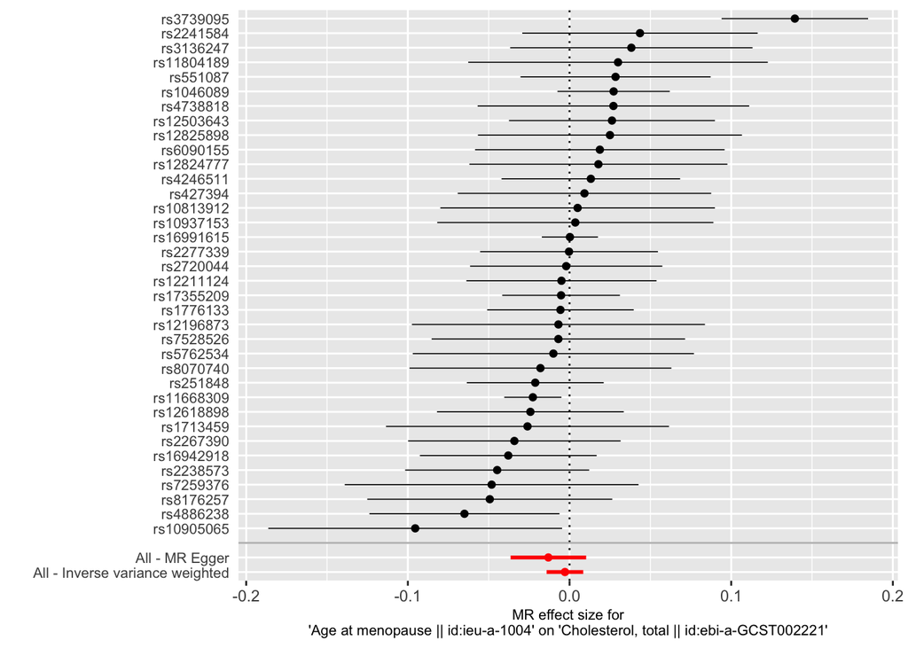

```r
p2_res_single_anm_to_tc <- mr_forest_plot(res_single_anm_to_tc)
p2_res_single_anm_to_tc[[1]]
```

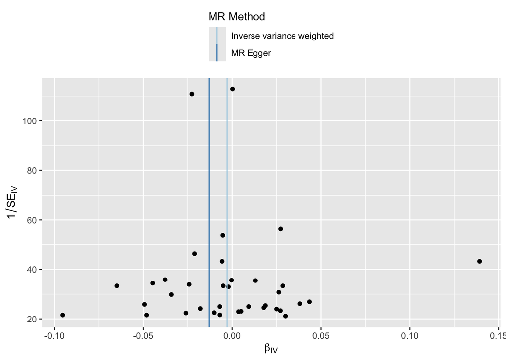

```r
p4_res_single_anm_to_tc <- mr_funnel_plot(res_single_anm_to_tc)
p4_res_single_anm_to_tc[[1]]
```

```r
res_loo_anm_to_tc <- mr_leaveoneout(data_anm_to_tc)
head(res_loo_anm_to_tc)
```

```
                           exposure                                   outcome
1 Age at menopause || id:ieu-a-1004 Cholesterol, total || id:ebi-a-GCST002221
2 Age at menopause || id:ieu-a-1004 Cholesterol, total || id:ebi-a-GCST002221
3 Age at menopause || id:ieu-a-1004 Cholesterol, total || id:ebi-a-GCST002221
4 Age at menopause || id:ieu-a-1004 Cholesterol, total || id:ebi-a-GCST002221
5 Age at menopause || id:ieu-a-1004 Cholesterol, total || id:ebi-a-GCST002221
6 Age at menopause || id:ieu-a-1004 Cholesterol, total || id:ebi-a-GCST002221
  id.exposure       id.outcome samplesize        SNP            b          se
1  ieu-a-1004 ebi-a-GCST002221      94595  rs1046089 -0.004539041 0.005894727
2  ieu-a-1004 ebi-a-GCST002221      94595 rs10813912 -0.002910534 0.005889864
3  ieu-a-1004 ebi-a-GCST002221      94595 rs10905065 -0.002110907 0.005715440
4  ieu-a-1004 ebi-a-GCST002221      94595 rs10937153 -0.002897013 0.005890047
5  ieu-a-1004 ebi-a-GCST002221      94595 rs11668309  0.002312021 0.006288061
6  ieu-a-1004 ebi-a-GCST002221      94595 rs11804189 -0.003088362 0.005866442
          p
1 0.4412897
2 0.6211933
3 0.7118787
4 0.6228262
5 0.7131087
6 0.5985787
```

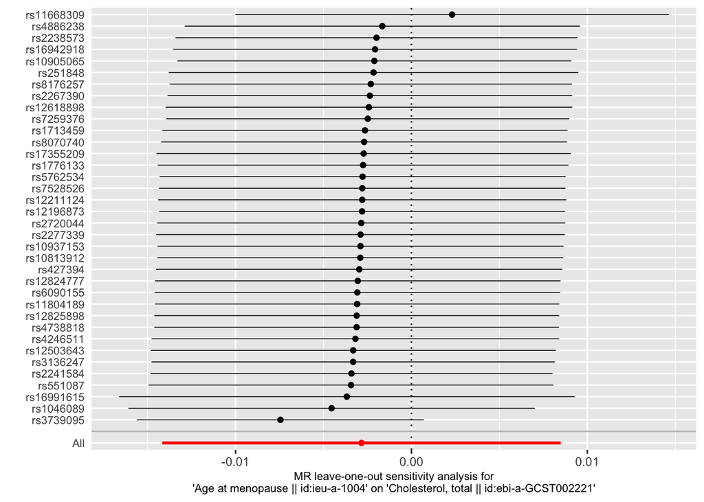

```r
p_loo_anm_to_tc <- mr_leaveoneout_plot(res_loo_anm_to_tc)
p_loo_anm_to_tc[[1]]
```

```r
out_anm_to_tc <- directionality_test(data_anm_to_tc)
```

```
r.exposure and/or r.outcome not present.
Calculating approximate SNP-exposure and/or SNP-outcome correlations, assuming all are quantitative traits. Please pre-calculate r.exposure and/or r.outcome using get_r_from_lor() for any binary traits
```

```r
out_anm_to_tc
```

```
  id.exposure       id.outcome                          exposure
1  ieu-a-1004 ebi-a-GCST002221 Age at menopause || id:ieu-a-1004
                                    outcome snp_r2.exposure snp_r2.outcome
1 Cholesterol, total || id:ebi-a-GCST002221      0.04007178   0.0007322501
  correct_causal_direction  steiger_pval
1                     TRUE 4.391643e-271
```